# Glue and S3 parameters

## Table analysis

The notebook uses the following Papermill parameters to update the notebook:

- `DatabaseName`: Name of the database
- `table_name`: Name of the table
- `partition_keys`: variables name to group to count the duplicates
- `keys`: Variable name to perform the grouping -> Only one variable for now, Variable name to perform the secondary grouping -> Only one variable for now
  - format: 'A,B'
- `proba`: Chi-square analysis probabilitity
- `y_var`: Continuous target variables
- `threshohld`: Percent of missing values. If the percentage of missing is above the threshold, their exclude from analysis.

Upload queries analytics

[output not shown]

[output cut: 119 more lines]

[output not shown]

## Check Duplicates

One of the most important step when creating a table is to check if the table contains duplicates. The cell below checks if the table generated before is empty of duplicates. The code uses the JSON file to create the query parsed in Athena.

You are required to define the group(s) that Athena will use to compute the duplicate. For instance, your table can be grouped by COL1 and COL2 (need to be string or varchar), then pass the list ['COL1', 'COL2']

|  | CNT | CNT_DUPLICATE |
| --- | --- | --- |
| 0 | 1 | 29495 |

# Analytics

In this part, we are providing basic summary statistic. Since we have created the tables, we can parse the schema in Glue and use our json file to automatically generates the analysis.

The cells below execute the job in the key `ANALYSIS`. You need to change the `primary_key` and `secondary_key`

## Count missing values

|  | total_missing | total_missing_pct |
| --- | --- | --- |
| nb_obs | 29495 | 100.00% |
| year | 0 | 0.00% |
| current_ratio_i | 0 | 0.00% |
| std_current_ratio_i | 0 | 0.00% |
| quick_ratio_i | 0 | 0.00% |
| std_quick_ratio_i | 0 | 0.00% |
| cash_ratio_i | 0 | 0.00% |
| std_cash_ratio_i | 0 | 0.00% |
| liabilities_assets_i | 0 | 0.00% |
| std_liabilities_assets_i | 0 | 0.00% |
| return_on_asset_i | 0 | 0.00% |
| std_return_on_asset_i | 0 | 0.00% |
| sales_assets_i | 0 | 0.00% |
| std_sales_assets_i | 0 | 0.00% |
| account_paybable_to_asset_i | 0 | 0.00% |
| std_account_paybable_to_asset_i | 0 | 0.00% |
| asset_tangibility_i | 0 | 0.00% |
| std_asset_tangibility_i | 0 | 0.00% |
| rd_intensity_i | 0 | 0.00% |
| std_rd_intensity_i | 0 | 0.00% |
| inventory_to_sales_i | 0 | 0.00% |
| std_inventory_to_sales_i | 0 | 0.00% |
| lower_location | 0 | 0.00% |
| larger_location | 0 | 0.00% |
| coastal | 0 | 0.00% |
| fe_c_i | 0 | 0.00% |
| fe_t_i | 0 | 0.00% |
| std_working_capital_requirement_i | 0 | 0.00% |
| working_capital_requirement_i | 0 | 0.00% |
| std_working_capital_i | 0 | 0.00% |
| tso2 | 0 | 0.00% |
| period | 0 | 0.00% |
| provinces | 0 | 0.00% |
| cityen | 0 | 0.00% |
| geocode4_corr | 0 | 0.00% |
| tcz | 0 | 0.00% |
| spz | 0 | 0.00% |
| ind2 | 0 | 0.00% |
| short | 0 | 0.00% |
| polluted_di | 0 | 0.00% |
| polluted_mi | 0 | 0.00% |
| polluted_mei | 0 | 0.00% |
| so2_intensity | 0 | 0.00% |
| working_capital_i | 0 | 0.00% |
| tso2_mandate_c | 0 | 0.00% |
| in_10_000_tonnes | 0 | 0.00% |
| output | 0 | 0.00% |
| employment | 0 | 0.00% |
| sales | 0 | 0.00% |
| capital | 0 | 0.00% |
| credit_constraint | 0 | 0.00% |
| receivable_curasset_i | 0 | 0.00% |
| std_receivable_curasset_i | 0 | 0.00% |
| cash_over_curasset_i | 0 | 0.00% |
| std_cash_over_curasset_i | 0 | 0.00% |
| fe_c_t | 0 | 0.00% |

Remove from the analysis all variables with a count of missing values above 50%. Note that, we exclude the first value since it is `nb_obs`

```
[]
```

# Brief description table

In this part, we provide a brief summary statistic from the lattest jobs. For the continuous analysis with a primary/secondary key, please add the relevant variables you want to know the count and distribution

## Categorical Description

During the categorical analysis, we wil count the number of observations for a given group and for a pair.

### Count obs by group

- Index: primary group
- nb_obs: Number of observations per primary group value
- percentage: Percentage of observation per primary group value over the total number of observations

Returns the top 10 only

```
Nb of obs for year, comment year from 2001 to 2007
```

| year | nb_obs | percentage |
| --- | --- | --- |
| 2007 | 4482 | 15.20% |
| 2004 | 4284 | 14.52% |
| 2005 | 4270 | 14.48% |
| 2003 | 4173 | 14.15% |
| 2002 | 4098 | 13.89% |
| 2006 | 4095 | 13.88% |
| 2001 | 4093 | 13.88% |

```
Nb of obs for period, comment False if year before 2005 included, True if year 2006 and 2007
```

| period | nb_obs | percentage |
| --- | --- | --- |
| False | 20918 | 70.92% |
| True | 8577 | 29.08% |

```
Nb of obs for provinces, comment
```

| provinces | nb_obs | percentage |
| --- | --- | --- |
| Shandong | 2385 | 8.09% |
| Guangdong | 2196 | 7.45% |
| Jiangsu | 1932 | 6.55% |
| Henan | 1779 | 6.03% |
| Sichuan | 1727 | 5.86% |
| Liaoning | 1710 | 5.80% |
| Zhejiang | 1570 | 5.32% |
| Hebei | 1449 | 4.91% |
| Hunan | 1427 | 4.84% |
| Hubei | 1318 | 4.47% |

```
Nb of obs for cityen, comment
```

| cityen | nb_obs | percentage |
| --- | --- | --- |
| Taizhou | 309 | 1.05% |
| Fuzhou | 268 | 0.91% |
| Suzhou | 208 | 0.71% |
| Tianjin | 197 | 0.67% |
| Shanghai | 194 | 0.66% |
| Chengdu | 190 | 0.64% |
| Harbin | 184 | 0.62% |
| Nanjing | 184 | 0.62% |
| Chongqing | 183 | 0.62% |
| Yantai | 180 | 0.61% |

```
Nb of obs for geocode4_corr, comment
```

| geocode4_corr | nb_obs | percentage |
| --- | --- | --- |
| 1201 | 197 | 0.67% |
| 3101 | 194 | 0.66% |
| 5101 | 190 | 0.64% |
| 3201 | 184 | 0.62% |
| 2301 | 184 | 0.62% |
| 5001 | 183 | 0.62% |
| 3706 | 180 | 0.61% |
| 3210 | 179 | 0.61% |
| 3701 | 179 | 0.61% |
| 3702 | 178 | 0.60% |

```
Nb of obs for tcz, comment Two control zone policy city
```

| tcz | nb_obs | percentage |
| --- | --- | --- |
| 1 | 17556 | 59.52% |
| 0 | 11939 | 40.48% |

```
Nb of obs for spz, comment Special policy zone policy city
```

| spz | nb_obs | percentage |
| --- | --- | --- |
| 0 | 20459 | 69.36% |
| 1 | 9036 | 30.64% |

```
Nb of obs for ind2, comment 2 digits industry
```

| ind2 | nb_obs | percentage |
| --- | --- | --- |
| 31 | 1896 | 6.43% |
| 26 | 1854 | 6.29% |
| 15 | 1725 | 5.85% |
| 22 | 1700 | 5.76% |
| 27 | 1638 | 5.55% |
| 17 | 1632 | 5.53% |
| 13 | 1611 | 5.46% |
| 14 | 1545 | 5.24% |
| 32 | 1411 | 4.78% |
| 35 | 1263 | 4.28% |

```
Nb of obs for short, comment
```

| short | nb_obs | percentage |
| --- | --- | --- |
| Non-metallic Products | 1896 | 6.43% |
| Raw Chemical Materials | 1854 | 6.29% |
| Beverages | 1725 | 5.85% |
| Paper | 1700 | 5.76% |
| Medicines | 1638 | 5.55% |
| Textile | 1632 | 5.53% |
| Processing foods | 1611 | 5.46% |
| Foods | 1545 | 5.24% |
| Smelting ferrous Metals | 1411 | 4.78% |
| Machinery | 1263 | 4.28% |

```
Nb of obs for polluted_di, comment Sectors with values above Yearly 75th percentile of SO2 label as ABOVE else BELOW
```

| polluted_di | nb_obs | percentage |
| --- | --- | --- |
| BELOW | 18952 | 64.25% |
| ABOVE | 10543 | 35.75% |

```
Nb of obs for polluted_mi, comment Sectors with values above Yearly average of SO2 label as ABOVE else BELOW
```

| polluted_mi | nb_obs | percentage |
| --- | --- | --- |
| BELOW | 18952 | 64.25% |
| ABOVE | 10543 | 35.75% |

```
Nb of obs for polluted_mei, comment Sectors with values above Yearly median of SO2 label as ABOVE else BELOW
```

| polluted_mei | nb_obs | percentage |
| --- | --- | --- |
| ABOVE | 20766 | 70.41% |
| BELOW | 8729 | 29.59% |

```
Nb of obs for lower_location, comment Location city. one of Coastal, Central, Northwest, Northeast, Southwest
```

| lower_location | nb_obs | percentage |
| --- | --- | --- |
| Coastal | 11282 | 38.25% |
| Central | 7915 | 26.84% |
| Southwest | 3950 | 13.39% |
| Northeast | 3508 | 11.89% |
| Northwest | 2840 | 9.63% |

```
Nb of obs for larger_location, comment Location city. one of Eastern, Central, Western
```

| larger_location | nb_obs | percentage |
| --- | --- | --- |
| Eastern | 15422 | 52.29% |
| Central | 7915 | 26.84% |
| Western | 6158 | 20.88% |

```
Nb of obs for coastal, comment City is bordered by sea or not
```

| coastal | nb_obs | percentage |
| --- | --- | --- |
| No | 15583 | 52.83% |
| Yes | 13912 | 47.17% |

### Count obs by two pair

You need to pass the primary group in the cell below

- Index: primary group
- Columns: Secondary key -> All the categorical variables in the dataset
- nb_obs: Number of observations per primary group value
- Total: Total number of observations per primary group value (sum by row)
- percentage: Percentage of observations per primary group value over the total number of observations per primary group value (sum by row)

Returns the top 10 only

```
Nb of obs for the primary group year and period, details False if year before 2005 included, True if year 2006 and 2007
```

| year | nb_obs 2001 | nb_obs 2002 | nb_obs 2003 | nb_obs 2004 | nb_obs 2005 | nb_obs 2006 | nb_obs 2007 | total | percentage 2001 | percentage 2002 | percentage 2003 | percentage 2004 | percentage 2005 | percentage 2006 | percentage 2007 |
| --- | --- | --- | --- | --- | --- | --- | --- | --- | --- | --- | --- | --- | --- | --- | --- |
| True | 0.00 | 0.00 | 0.00 | 0.00 | 0.00 | 4,095.00 | 4,482.00 | 8,577.00 | 0.00% | 0.00% | 0.00% | 0.00% | 0.00% | 47.74% | 52.26% |
| False | 4,093.00 | 4,098.00 | 4,173.00 | 4,284.00 | 4,270.00 | 0.00 | 0.00 | 20,918.00 | 19.57% | 19.59% | 19.95% | 20.48% | 20.41% | 0.00% | 0.00% |

```
Nb of obs for the primary group year and provinces, details
```

| year | nb_obs 2001 | nb_obs 2002 | nb_obs 2003 | nb_obs 2004 | nb_obs 2005 | nb_obs 2006 | nb_obs 2007 | total | percentage 2001 | percentage 2002 | percentage 2003 | percentage 2004 | percentage 2005 | percentage 2006 | percentage 2007 |
| --- | --- | --- | --- | --- | --- | --- | --- | --- | --- | --- | --- | --- | --- | --- | --- |
| Hubei | 189.00 | 196.00 | 195.00 | 185.00 | 182.00 | 183.00 | 188.00 | 1,318.00 | 14.34% | 14.87% | 14.80% | 14.04% | 13.81% | 13.88% | 14.26% |
| Hunan | 198.00 | 194.00 | 207.00 | 215.00 | 208.00 | 200.00 | 205.00 | 1,427.00 | 13.88% | 13.59% | 14.51% | 15.07% | 14.58% | 14.02% | 14.37% |
| Hebei | 199.00 | 205.00 | 201.00 | 207.00 | 216.00 | 206.00 | 215.00 | 1,449.00 | 13.73% | 14.15% | 13.87% | 14.29% | 14.91% | 14.22% | 14.84% |
| Zhejiang | 215.00 | 211.00 | 222.00 | 220.00 | 223.00 | 237.00 | 242.00 | 1,570.00 | 13.69% | 13.44% | 14.14% | 14.01% | 14.20% | 15.10% | 15.41% |
| Liaoning | 239.00 | 237.00 | 233.00 | 237.00 | 246.00 | 254.00 | 264.00 | 1,710.00 | 13.98% | 13.86% | 13.63% | 13.86% | 14.39% | 14.85% | 15.44% |
| Sichuan | 234.00 | 233.00 | 248.00 | 247.00 | 251.00 | 247.00 | 267.00 | 1,727.00 | 13.55% | 13.49% | 14.36% | 14.30% | 14.53% | 14.30% | 15.46% |
| Henan | 257.00 | 254.00 | 253.00 | 256.00 | 250.00 | 253.00 | 256.00 | 1,779.00 | 14.45% | 14.28% | 14.22% | 14.39% | 14.05% | 14.22% | 14.39% |
| Jiangsu | 280.00 | 277.00 | 277.00 | 273.00 | 274.00 | 269.00 | 282.00 | 1,932.00 | 14.49% | 14.34% | 14.34% | 14.13% | 14.18% | 13.92% | 14.60% |
| Guangdong | 308.00 | 302.00 | 320.00 | 311.00 | 299.00 | 304.00 | 352.00 | 2,196.00 | 14.03% | 13.75% | 14.57% | 14.16% | 13.62% | 13.84% | 16.03% |
| Shandong | 338.00 | 340.00 | 347.00 | 349.00 | 341.00 | 339.00 | 331.00 | 2,385.00 | 14.17% | 14.26% | 14.55% | 14.63% | 14.30% | 14.21% | 13.88% |

```
Nb of obs for the primary group year and cityen, details
```

| year | nb_obs 2001 | nb_obs 2002 | nb_obs 2003 | nb_obs 2004 | nb_obs 2005 | nb_obs 2006 | nb_obs 2007 | total | percentage 2001 | percentage 2002 | percentage 2003 | percentage 2004 | percentage 2005 | percentage 2006 | percentage 2007 |
| --- | --- | --- | --- | --- | --- | --- | --- | --- | --- | --- | --- | --- | --- | --- | --- |
| Jinan | 25.00 | 26.00 | 27.00 | 27.00 | 26.00 | 25.00 | 23.00 | 179.00 | 13.97% | 14.53% | 15.08% | 15.08% | 14.53% | 13.97% | 12.85% |
| Yantai | 26.00 | 26.00 | 27.00 | 26.00 | 26.00 | 26.00 | 23.00 | 180.00 | 14.44% | 14.44% | 15.00% | 14.44% | 14.44% | 14.44% | 12.78% |
| Chongqing | 25.00 | 26.00 | 26.00 | 27.00 | 27.00 | 26.00 | 26.00 | 183.00 | 13.66% | 14.21% | 14.21% | 14.75% | 14.75% | 14.21% | 14.21% |
| Harbin | 28.00 | 28.00 | 28.00 | 26.00 | 23.00 | 26.00 | 25.00 | 184.00 | 15.22% | 15.22% | 15.22% | 14.13% | 12.50% | 14.13% | 13.59% |
| Chengdu | 27.00 | 27.00 | 27.00 | 25.00 | 27.00 | 29.00 | 28.00 | 190.00 | 14.21% | 14.21% | 14.21% | 13.16% | 14.21% | 15.26% | 14.74% |
| Shanghai | 27.00 | 27.00 | 28.00 | 29.00 | 28.00 | 28.00 | 27.00 | 194.00 | 13.92% | 13.92% | 14.43% | 14.95% | 14.43% | 14.43% | 13.92% |
| Tianjin | 27.00 | 28.00 | 29.00 | 29.00 | 28.00 | 28.00 | 28.00 | 197.00 | 13.71% | 14.21% | 14.72% | 14.72% | 14.21% | 14.21% | 14.21% |
| Suzhou | 30.00 | 28.00 | 31.00 | 30.00 | 31.00 | 23.00 | 35.00 | 208.00 | 14.42% | 13.46% | 14.90% | 14.42% | 14.90% | 11.06% | 16.83% |
| Fuzhou | 39.00 | 38.00 | 38.00 | 36.00 | 40.00 | 37.00 | 40.00 | 268.00 | 14.55% | 14.18% | 14.18% | 13.43% | 14.93% | 13.81% | 14.93% |
| Taizhou | 40.00 | 41.00 | 45.00 | 45.00 | 45.00 | 45.00 | 48.00 | 309.00 | 12.94% | 13.27% | 14.56% | 14.56% | 14.56% | 14.56% | 15.53% |

```
Nb of obs for the primary group year and geocode4_corr, details
```

| year geocode4_corr | nb_obs 2001 | nb_obs 2002 | nb_obs 2003 | nb_obs 2004 | nb_obs 2005 | nb_obs 2006 | nb_obs 2007 | total | percentage 2001 | percentage 2002 | percentage 2003 | percentage 2004 | percentage 2005 | percentage 2006 | percentage 2007 |
| --- | --- | --- | --- | --- | --- | --- | --- | --- | --- | --- | --- | --- | --- | --- | --- |
| 1201 | 27.00 | 28.00 | 29.00 | 29.00 | 28.00 | 28.00 | 28.00 | 197.00 | 13.71% | 14.21% | 14.72% | 14.72% | 14.21% | 14.21% | 14.21% |
| 2101 | 25.00 | 23.00 | 24.00 | 23.00 | 26.00 | 28.00 | 28.00 | 177.00 | 14.12% | 12.99% | 13.56% | 12.99% | 14.69% | 15.82% | 15.82% |
| 2301 | 28.00 | 28.00 | 28.00 | 26.00 | 23.00 | 26.00 | 25.00 | 184.00 | 15.22% | 15.22% | 15.22% | 14.13% | 12.50% | 14.13% | 13.59% |
| 3101 | 27.00 | 27.00 | 28.00 | 29.00 | 28.00 | 28.00 | 27.00 | 194.00 | 13.92% | 13.92% | 14.43% | 14.95% | 14.43% | 14.43% | 13.92% |
| 3701 | 25.00 | 26.00 | 27.00 | 27.00 | 26.00 | 25.00 | 23.00 | 179.00 | 13.97% | 14.53% | 15.08% | 15.08% | 14.53% | 13.97% | 12.85% |
| 3702 | 27.00 | 27.00 | 25.00 | 25.00 | 26.00 | 24.00 | 24.00 | 178.00 | 15.17% | 15.17% | 14.04% | 14.04% | 14.61% | 13.48% | 13.48% |
| 3706 | 26.00 | 26.00 | 27.00 | 26.00 | 26.00 | 26.00 | 23.00 | 180.00 | 14.44% | 14.44% | 15.00% | 14.44% | 14.44% | 14.44% | 12.78% |
| 4301 | 25.00 | 25.00 | 27.00 | 26.00 | 24.00 | 24.00 | 22.00 | 173.00 | 14.45% | 14.45% | 15.61% | 15.03% | 13.87% | 13.87% | 12.72% |
| 5001 | 25.00 | 26.00 | 26.00 | 27.00 | 27.00 | 26.00 | 26.00 | 183.00 | 13.66% | 14.21% | 14.21% | 14.75% | 14.75% | 14.21% | 14.21% |
| 5101 | 27.00 | 27.00 | 27.00 | 25.00 | 27.00 | 29.00 | 28.00 | 190.00 | 14.21% | 14.21% | 14.21% | 13.16% | 14.21% | 15.26% | 14.74% |

```
Nb of obs for the primary group year and tcz, details Two control zone policy city
```

| year tcz | nb_obs 2001 | nb_obs 2002 | nb_obs 2003 | nb_obs 2004 | nb_obs 2005 | nb_obs 2006 | nb_obs 2007 | total | percentage 2001 | percentage 2002 | percentage 2003 | percentage 2004 | percentage 2005 | percentage 2006 | percentage 2007 |
| --- | --- | --- | --- | --- | --- | --- | --- | --- | --- | --- | --- | --- | --- | --- | --- |
| 0 | 1,618.00 | 1,648.00 | 1,680.00 | 1,758.00 | 1,743.00 | 1,626.00 | 1,866.00 | 11,939.00 | 13.55% | 13.80% | 14.07% | 14.72% | 14.60% | 13.62% | 15.63% |
| 1 | 2,475.00 | 2,450.00 | 2,493.00 | 2,526.00 | 2,527.00 | 2,469.00 | 2,616.00 | 17,556.00 | 14.10% | 13.96% | 14.20% | 14.39% | 14.39% | 14.06% | 14.90% |

```
Nb of obs for the primary group year and spz, details Special policy zone policy city
```

| year spz | nb_obs 2001 | nb_obs 2002 | nb_obs 2003 | nb_obs 2004 | nb_obs 2005 | nb_obs 2006 | nb_obs 2007 | total | percentage 2001 | percentage 2002 | percentage 2003 | percentage 2004 | percentage 2005 | percentage 2006 | percentage 2007 |
| --- | --- | --- | --- | --- | --- | --- | --- | --- | --- | --- | --- | --- | --- | --- | --- |
| 0 | 2,776.00 | 2,790.00 | 2,865.00 | 2,979.00 | 2,994.00 | 2,862.00 | 3,193.00 | 20,459.00 | 13.57% | 13.64% | 14.00% | 14.56% | 14.63% | 13.99% | 15.61% |
| 1 | 1,317.00 | 1,308.00 | 1,308.00 | 1,305.00 | 1,276.00 | 1,233.00 | 1,289.00 | 9,036.00 | 14.58% | 14.48% | 14.48% | 14.44% | 14.12% | 13.65% | 14.27% |

```
Nb of obs for the primary group year and ind2, details 2 digits industry
```

| year ind2 | nb_obs 2001 | nb_obs 2002 | nb_obs 2003 | nb_obs 2004 | nb_obs 2005 | nb_obs 2006 | nb_obs 2007 | total | percentage 2001 | percentage 2002 | percentage 2003 | percentage 2004 | percentage 2005 | percentage 2006 | percentage 2007 |
| --- | --- | --- | --- | --- | --- | --- | --- | --- | --- | --- | --- | --- | --- | --- | --- |
| 13 | 225.00 | 150.00 | 239.00 | 251.00 | 247.00 | 242.00 | 257.00 | 1,611.00 | 13.97% | 9.31% | 14.84% | 15.58% | 15.33% | 15.02% | 15.95% |
| 14 | 206.00 | 222.00 | 216.00 | 222.00 | 222.00 | 213.00 | 244.00 | 1,545.00 | 13.33% | 14.37% | 13.98% | 14.37% | 14.37% | 13.79% | 15.79% |
| 15 | 235.00 | 240.00 | 234.00 | 251.00 | 258.00 | 245.00 | 262.00 | 1,725.00 | 13.62% | 13.91% | 13.57% | 14.55% | 14.96% | 14.20% | 15.19% |
| 17 | 228.00 | 233.00 | 231.00 | 241.00 | 239.00 | 222.00 | 238.00 | 1,632.00 | 13.97% | 14.28% | 14.15% | 14.77% | 14.64% | 13.60% | 14.58% |
| 22 | 229.00 | 236.00 | 233.00 | 250.00 | 249.00 | 243.00 | 260.00 | 1,700.00 | 13.47% | 13.88% | 13.71% | 14.71% | 14.65% | 14.29% | 15.29% |
| 26 | 256.00 | 260.00 | 260.00 | 273.00 | 274.00 | 258.00 | 273.00 | 1,854.00 | 13.81% | 14.02% | 14.02% | 14.72% | 14.78% | 13.92% | 14.72% |
| 27 | 222.00 | 222.00 | 229.00 | 240.00 | 241.00 | 231.00 | 253.00 | 1,638.00 | 13.55% | 13.55% | 13.98% | 14.65% | 14.71% | 14.10% | 15.45% |
| 31 | 258.00 | 267.00 | 266.00 | 281.00 | 282.00 | 263.00 | 279.00 | 1,896.00 | 13.61% | 14.08% | 14.03% | 14.82% | 14.87% | 13.87% | 14.72% |
| 32 | 179.00 | 186.00 | 189.00 | 204.00 | 206.00 | 211.00 | 236.00 | 1,411.00 | 12.69% | 13.18% | 13.39% | 14.46% | 14.60% | 14.95% | 16.73% |
| 35 | 190.00 | 189.00 | 185.00 | 183.00 | 180.00 | 158.00 | 178.00 | 1,263.00 | 15.04% | 14.96% | 14.65% | 14.49% | 14.25% | 12.51% | 14.09% |

```
Nb of obs for the primary group year and short, details
```

| year | nb_obs 2001 | nb_obs 2002 | nb_obs 2003 | nb_obs 2004 | nb_obs 2005 | nb_obs 2006 | nb_obs 2007 | total | percentage 2001 | percentage 2002 | percentage 2003 | percentage 2004 | percentage 2005 | percentage 2006 | percentage 2007 |
| --- | --- | --- | --- | --- | --- | --- | --- | --- | --- | --- | --- | --- | --- | --- | --- |
| Machinery | 190.00 | 189.00 | 185.00 | 183.00 | 180.00 | 158.00 | 178.00 | 1,263.00 | 15.04% | 14.96% | 14.65% | 14.49% | 14.25% | 12.51% | 14.09% |
| Smelting ferrous Metals | 179.00 | 186.00 | 189.00 | 204.00 | 206.00 | 211.00 | 236.00 | 1,411.00 | 12.69% | 13.18% | 13.39% | 14.46% | 14.60% | 14.95% | 16.73% |
| Foods | 206.00 | 222.00 | 216.00 | 222.00 | 222.00 | 213.00 | 244.00 | 1,545.00 | 13.33% | 14.37% | 13.98% | 14.37% | 14.37% | 13.79% | 15.79% |
| Processing foods | 225.00 | 150.00 | 239.00 | 251.00 | 247.00 | 242.00 | 257.00 | 1,611.00 | 13.97% | 9.31% | 14.84% | 15.58% | 15.33% | 15.02% | 15.95% |
| Textile | 228.00 | 233.00 | 231.00 | 241.00 | 239.00 | 222.00 | 238.00 | 1,632.00 | 13.97% | 14.28% | 14.15% | 14.77% | 14.64% | 13.60% | 14.58% |
| Medicines | 222.00 | 222.00 | 229.00 | 240.00 | 241.00 | 231.00 | 253.00 | 1,638.00 | 13.55% | 13.55% | 13.98% | 14.65% | 14.71% | 14.10% | 15.45% |
| Paper | 229.00 | 236.00 | 233.00 | 250.00 | 249.00 | 243.00 | 260.00 | 1,700.00 | 13.47% | 13.88% | 13.71% | 14.71% | 14.65% | 14.29% | 15.29% |
| Beverages | 235.00 | 240.00 | 234.00 | 251.00 | 258.00 | 245.00 | 262.00 | 1,725.00 | 13.62% | 13.91% | 13.57% | 14.55% | 14.96% | 14.20% | 15.19% |
| Raw Chemical Materials | 256.00 | 260.00 | 260.00 | 273.00 | 274.00 | 258.00 | 273.00 | 1,854.00 | 13.81% | 14.02% | 14.02% | 14.72% | 14.78% | 13.92% | 14.72% |
| Non-metallic Products | 258.00 | 267.00 | 266.00 | 281.00 | 282.00 | 263.00 | 279.00 | 1,896.00 | 13.61% | 14.08% | 14.03% | 14.82% | 14.87% | 13.87% | 14.72% |

```
Nb of obs for the primary group year and polluted_di, details Sectors with values above Yearly 75th percentile of SO2 label as ABOVE else BELOW
```

| year polluted_di | nb_obs 2001 | nb_obs 2002 | nb_obs 2003 | nb_obs 2004 | nb_obs 2005 | nb_obs 2006 | nb_obs 2007 | total | percentage 2001 | percentage 2002 | percentage 2003 | percentage 2004 | percentage 2005 | percentage 2006 | percentage 2007 |
| --- | --- | --- | --- | --- | --- | --- | --- | --- | --- | --- | --- | --- | --- | --- | --- |
| ABOVE | 1,392.00 | 1,445.00 | 1,454.00 | 1,540.00 | 1,566.00 | 1,513.00 | 1,633.00 | 10,543.00 | 13.20% | 13.71% | 13.79% | 14.61% | 14.85% | 14.35% | 15.49% |
| BELOW | 2,701.00 | 2,653.00 | 2,719.00 | 2,744.00 | 2,704.00 | 2,582.00 | 2,849.00 | 18,952.00 | 14.25% | 14.00% | 14.35% | 14.48% | 14.27% | 13.62% | 15.03% |

```
Nb of obs for the primary group year and polluted_mi, details Sectors with values above Yearly average of SO2 label as ABOVE else BELOW
```

| year polluted_mi | nb_obs 2001 | nb_obs 2002 | nb_obs 2003 | nb_obs 2004 | nb_obs 2005 | nb_obs 2006 | nb_obs 2007 | total | percentage 2001 | percentage 2002 | percentage 2003 | percentage 2004 | percentage 2005 | percentage 2006 | percentage 2007 |
| --- | --- | --- | --- | --- | --- | --- | --- | --- | --- | --- | --- | --- | --- | --- | --- |
| ABOVE | 1,392.00 | 1,445.00 | 1,454.00 | 1,540.00 | 1,566.00 | 1,513.00 | 1,633.00 | 10,543.00 | 13.20% | 13.71% | 13.79% | 14.61% | 14.85% | 14.35% | 15.49% |
| BELOW | 2,701.00 | 2,653.00 | 2,719.00 | 2,744.00 | 2,704.00 | 2,582.00 | 2,849.00 | 18,952.00 | 14.25% | 14.00% | 14.35% | 14.48% | 14.27% | 13.62% | 15.03% |

```
Nb of obs for the primary group year and polluted_mei, details Sectors with values above Yearly median of SO2 label as ABOVE else BELOW
```

| year | nb_obs 2001 | nb_obs 2002 | nb_obs 2003 | nb_obs 2004 | nb_obs 2005 | nb_obs 2006 | nb_obs 2007 | total | percentage 2001 | percentage 2002 | percentage 2003 | percentage 2004 | percentage 2005 | percentage 2006 | percentage 2007 |
| --- | --- | --- | --- | --- | --- | --- | --- | --- | --- | --- | --- | --- | --- | --- | --- |
| BELOW | 1,257.00 | 1,262.00 | 1,267.00 | 1,259.00 | 1,214.00 | 1,172.00 | 1,298.00 | 8,729.00 | 14.40% | 14.46% | 14.51% | 14.42% | 13.91% | 13.43% | 14.87% |
| ABOVE | 2,836.00 | 2,836.00 | 2,906.00 | 3,025.00 | 3,056.00 | 2,923.00 | 3,184.00 | 20,766.00 | 13.66% | 13.66% | 13.99% | 14.57% | 14.72% | 14.08% | 15.33% |

```
Nb of obs for the primary group year and lower_location, details Location city. one of Coastal, Central, Northwest, Northeast, Southwest
```

| year | nb_obs 2001 | nb_obs 2002 | nb_obs 2003 | nb_obs 2004 | nb_obs 2005 | nb_obs 2006 | nb_obs 2007 | total | percentage 2001 | percentage 2002 | percentage 2003 | percentage 2004 | percentage 2005 | percentage 2006 | percentage 2007 |
| --- | --- | --- | --- | --- | --- | --- | --- | --- | --- | --- | --- | --- | --- | --- | --- |
| Northwest | 354.00 | 370.00 | 359.00 | 443.00 | 437.00 | 441.00 | 436.00 | 2,840.00 | 12.46% | 13.03% | 12.64% | 15.60% | 15.39% | 15.53% | 15.35% |
| Northeast | 512.00 | 497.00 | 485.00 | 486.00 | 492.00 | 508.00 | 528.00 | 3,508.00 | 14.60% | 14.17% | 13.83% | 13.85% | 14.03% | 14.48% | 15.05% |
| Southwest | 503.00 | 527.00 | 564.00 | 578.00 | 581.00 | 584.00 | 613.00 | 3,950.00 | 12.73% | 13.34% | 14.28% | 14.63% | 14.71% | 14.78% | 15.52% |
| Central | 1,144.00 | 1,128.00 | 1,166.00 | 1,157.00 | 1,152.00 | 949.00 | 1,219.00 | 7,915.00 | 14.45% | 14.25% | 14.73% | 14.62% | 14.55% | 11.99% | 15.40% |
| Coastal | 1,580.00 | 1,576.00 | 1,599.00 | 1,620.00 | 1,608.00 | 1,613.00 | 1,686.00 | 11,282.00 | 14.00% | 13.97% | 14.17% | 14.36% | 14.25% | 14.30% | 14.94% |

```
Nb of obs for the primary group year and larger_location, details Location city. one of Eastern, Central, Western
```

| year | nb_obs 2001 | nb_obs 2002 | nb_obs 2003 | nb_obs 2004 | nb_obs 2005 | nb_obs 2006 | nb_obs 2007 | total | percentage 2001 | percentage 2002 | percentage 2003 | percentage 2004 | percentage 2005 | percentage 2006 | percentage 2007 |
| --- | --- | --- | --- | --- | --- | --- | --- | --- | --- | --- | --- | --- | --- | --- | --- |
| Western | 781.00 | 822.00 | 846.00 | 929.00 | 917.00 | 920.00 | 943.00 | 6,158.00 | 12.68% | 13.35% | 13.74% | 15.09% | 14.89% | 14.94% | 15.31% |
| Central | 1,144.00 | 1,128.00 | 1,166.00 | 1,157.00 | 1,152.00 | 949.00 | 1,219.00 | 7,915.00 | 14.45% | 14.25% | 14.73% | 14.62% | 14.55% | 11.99% | 15.40% |
| Eastern | 2,168.00 | 2,148.00 | 2,161.00 | 2,198.00 | 2,201.00 | 2,226.00 | 2,320.00 | 15,422.00 | 14.06% | 13.93% | 14.01% | 14.25% | 14.27% | 14.43% | 15.04% |

```
Nb of obs for the primary group year and coastal, details City is bordered by sea or not
```

| year | nb_obs 2001 | nb_obs 2002 | nb_obs 2003 | nb_obs 2004 | nb_obs 2005 | nb_obs 2006 | nb_obs 2007 | total | percentage 2001 | percentage 2002 | percentage 2003 | percentage 2004 | percentage 2005 | percentage 2006 | percentage 2007 |
| --- | --- | --- | --- | --- | --- | --- | --- | --- | --- | --- | --- | --- | --- | --- | --- |
| Yes | 1,912.00 | 1,936.00 | 1,990.00 | 1,984.00 | 1,991.00 | 2,004.00 | 2,095.00 | 13,912.00 | 13.74% | 13.92% | 14.30% | 14.26% | 14.31% | 14.40% | 15.06% |
| No | 2,181.00 | 2,162.00 | 2,183.00 | 2,300.00 | 2,279.00 | 2,091.00 | 2,387.00 | 15,583.00 | 14.00% | 13.87% | 14.01% | 14.76% | 14.62% | 13.42% | 15.32% |

## Continuous description

There are three possibilities to show the ditribution of a continuous variables:

1. Display the percentile
2. Display the percentile, with one primary key
3. Display the percentile, with one primary key, and a secondary key

### 1. Display the percentile

| pct | tso2 | so2_intensity | tso2_mandate_c | in_10_000_tonnes | credit_constraint | receivable_curasset_i | std_receivable_curasset_i | cash_over_curasset_i | std_cash_over_curasset_i | working_capital_i | std_working_capital_i | working_capital_requirement_i | std_working_capital_requirement_i | current_ratio_i | std_current_ratio_i | quick_ratio_i | std_quick_ratio_i | cash_ratio_i | std_cash_ratio_i | liabilities_assets_i | std_liabilities_assets_i | return_on_asset_i | std_return_on_asset_i | sales_assets_i | std_sales_assets_i | account_paybable_to_asset_i | std_account_paybable_to_asset_i | asset_tangibility_i | std_asset_tangibility_i | … |
| --- | --- | --- | --- | --- | --- | --- | --- | --- | --- | --- | --- | --- | --- | --- | --- | --- | --- | --- | --- | --- | --- | --- | --- | --- | --- | --- | --- | --- | --- | --- |
| 0.01 | 2503.00 | 0.00 | 0.00 | 0.00 | -2.59 | 0.07 | -2.04 | 0.25 | -0.94 | -93.42 | -2.38 | 18.52 | -0.73 | 0.89 | -0.93 | 0.58 | -1.97 | 0.40 | -1.04 | 0.29 | -3.91 | -0.06 | -1.07 | -42.51 | -2.26 | 0.08 | -0.66 | 37.69 | -0.69 | … |
| 0.05 | 4815.00 | 0.01 | 0.00 | 0.03 | -1.54 | 0.10 | -1.62 | 0.25 | -0.91 | -9.14 | -0.61 | 24.12 | -0.65 | 0.91 | -0.87 | 0.65 | -1.27 | 0.40 | -1.03 | 0.49 | -0.80 | -0.06 | -1.02 | 11.55 | -0.23 | 0.11 | -0.56 | 57.46 | -0.62 | … |
| 0.1 | 8800.00 | 0.01 | 0.01 | 0.10 | -1.11 | 0.13 | -1.21 | 0.26 | -0.84 | -8.02 | -0.59 | 34.10 | -0.51 | 0.96 | -0.67 | 0.67 | -1.13 | 0.41 | -0.94 | 0.50 | -0.67 | -0.02 | -0.53 | 11.66 | -0.22 | 0.15 | -0.43 | 78.73 | -0.55 | … |
| 0.2 | 20479.00 | 0.03 | 0.02 | 0.22 | -0.72 | 0.17 | -0.73 | 0.27 | -0.79 | 0.90 | -0.40 | 41.08 | -0.41 | 1.00 | -0.47 | 0.68 | -1.02 | 0.45 | -0.66 | 0.52 | -0.35 | -0.00 | -0.33 | 13.76 | -0.14 | 0.17 | -0.35 | 126.86 | -0.38 | … |
| 0.25 | 29607.00 | 0.05 | 0.03 | 0.27 | -0.72 | 0.17 | -0.71 | 0.28 | -0.72 | 4.13 | -0.33 | 51.79 | -0.26 | 1.01 | -0.45 | 0.69 | -0.99 | 0.45 | -0.66 | 0.54 | -0.17 | 0.00 | -0.28 | 13.80 | -0.14 | 0.18 | -0.30 | 140.09 | -0.34 | … |
| 0.3 | 40814.00 | 0.07 | 0.04 | 0.35 | -0.65 | 0.21 | -0.25 | 0.29 | -0.63 | 4.13 | -0.33 | 51.79 | -0.26 | 1.04 | -0.31 | 0.70 | -0.92 | 0.45 | -0.61 | 0.55 | 0.03 | 0.00 | -0.26 | 14.44 | -0.12 | 0.19 | -0.28 | 140.09 | -0.34 | … |
| 0.4 | 76543.00 | 0.13 | 0.06 | 0.57 | -0.47 | 0.21 | -0.19 | 0.31 | -0.54 | 12.43 | -0.15 | 76.16 | 0.09 | 1.08 | -0.14 | 0.72 | -0.68 | 0.46 | -0.60 | 0.56 | 0.14 | 0.01 | -0.23 | 15.24 | -0.09 | 0.19 | -0.27 | 189.82 | -0.17 | … |
| 0.5 | 137599.00 | 0.23 | 0.08 | 0.80 | -0.44 | 0.23 | 0.02 | 0.32 | -0.43 | 14.88 | -0.10 | 95.59 | 0.36 | 1.09 | -0.09 | 0.77 | -0.29 | 0.48 | -0.41 | 0.56 | 0.22 | 0.01 | -0.18 | 15.75 | -0.07 | 0.21 | -0.21 | 216.20 | -0.08 | … |
| 0.6 | 247807.00 | 0.41 | 0.10 | 1.04 | -0.32 | 0.27 | 0.52 | 0.36 | -0.18 | 20.58 | 0.02 | 107.42 | 0.53 | 1.12 | 0.04 | 0.79 | -0.08 | 0.49 | -0.34 | 0.58 | 0.55 | 0.02 | -0.03 | 16.85 | -0.03 | 0.21 | -0.18 | 236.51 | -0.01 | … |
| 0.7 | 473087.00 | 0.75 | 0.15 | 1.48 | -0.27 | 0.28 | 0.63 | 0.38 | -0.09 | 36.76 | 0.36 | 135.77 | 0.93 | 1.15 | 0.17 | 0.80 | 0.00 | 0.52 | -0.09 | 0.59 | 0.62 | 0.03 | 0.02 | 19.06 | 0.05 | 0.24 | -0.09 | 307.49 | 0.23 | … |
| 0.75 | 688127.00 | 1.03 | 0.18 | 1.76 | -0.23 | 0.29 | 0.75 | 0.38 | -0.09 | 43.27 | 0.49 | 160.04 | 1.28 | 1.17 | 0.23 | 0.80 | 0.02 | 0.53 | -0.01 | 0.59 | 0.70 | 0.03 | 0.06 | 19.54 | 0.07 | 0.24 | -0.08 | 444.79 | 0.69 | … |
| 0.8 | 1050623.00 | 1.48 | 0.21 | 1.99 | -0.23 | 0.30 | 0.86 | 0.38 | -0.08 | 47.25 | 0.58 | 166.94 | 1.37 | 1.17 | 0.25 | 0.82 | 0.15 | 0.54 | 0.06 | 0.59 | 0.72 | 0.03 | 0.06 | 19.88 | 0.09 | 0.33 | 0.23 | 488.28 | 0.84 | … |
| 0.9 | 3366911.00 | 3.84 | 0.35 | 3.39 | 0.07 | 0.30 | 0.94 | 0.40 | 0.10 | 91.46 | 1.51 | 181.30 | 1.58 | 1.19 | 0.33 | 0.88 | 0.71 | 0.55 | 0.13 | 0.61 | 0.93 | 0.05 | 0.29 | 25.16 | 0.28 | 0.39 | 0.45 | 636.01 | 1.34 | … |
| 0.95 | 7110655.00 | 8.25 | 0.45 | 4.45 | 0.33 | 0.34 | 1.42 | 0.43 | 0.29 | 108.50 | 1.87 | 232.20 | 2.30 | 1.21 | 0.41 | 0.91 | 0.94 | 0.57 | 0.26 | 0.62 | 1.07 | 0.07 | 0.59 | 25.67 | 0.30 | 0.47 | 0.77 | 636.01 | 1.34 | … |
| 0.99 | 22020095.00 | 42.00 | 1.00 | 9.38 | 0.62 | 0.42 | 2.39 | 0.47 | 0.53 | 180.98 | 3.40 | 234.04 | 2.33 | 2.35 | 5.26 | 1.21 | 3.57 | 1.03 | 3.79 | 0.62 | 1.10 | 0.44 | 5.03 | 29.20 | 0.44 | 0.76 | 1.79 | 887.00 | 2.19 | … |

### 2. Display the percentile, with one primary key

The primary key will be passed to all the continuous variables

|  | year pct | 2001 | 2002 | 2003 | 2004 | 2005 | 2006 | 2007 |
| --- | --- | --- | --- | --- | --- | --- | --- | --- |
| tso2 | 0.01 | 2,429.00 | 2,560.00 | 2,560.00 | 2,496.00 | 2,472.00 | 2,380.00 | 2,500.00 |
|  | 0.05 | 4,640.00 | 4,800.00 | 4,681.00 | 4,800.00 | 4,923.00 | 5,000.00 | 5,226.00 |
|  | 0.1 | 8,000.00 | 8,486.00 | 8,020.00 | 8,802.00 | 9,120.00 | 9,075.00 | 9,583.00 |
|  | 0.25 | 28,624.00 | 28,849.00 | 26,340.00 | 28,316.00 | 30,600.00 | 29,856.00 | 33,792.00 |
|  | 0.5 | 132,928.00 | 127,968.00 | 117,641.00 | 135,506.00 | 141,090.00 | 147,904.00 | 156,675.00 |
|  | 0.75 | 605,825.00 | 595,460.00 | 597,356.00 | 658,507.00 | 737,429.00 | 811,500.00 | 786,490.00 |
|  | 0.95 | 5,886,538.00 | 5,435,356.00 | 5,749,010.00 | 7,225,092.00 | 7,914,485.00 | 8,759,112.00 | 7,844,990.00 |
|  | 0.99 | 19,011,542.00 | 18,089,683.00 | 19,046,520.00 | 23,868,501.00 | 22,840,262.00 | 23,591,572.00 | 22,693,016.00 |
| so2_intensity | 0.01 | 0.00 | 0.00 | 0.00 | 0.00 | 0.00 | 0.00 | 0.00 |
|  | 0.05 | 0.01 | 0.01 | 0.01 | 0.01 | 0.00 | 0.00 | 0.00 |
|  | 0.1 | 0.02 | 0.02 | 0.02 | 0.01 | 0.01 | 0.01 | 0.01 |
|  | 0.25 | 0.09 | 0.08 | 0.06 | 0.05 | 0.04 | 0.03 | 0.03 |
|  | 0.5 | 0.40 | 0.38 | 0.26 | 0.22 | 0.18 | 0.15 | 0.13 |
|  | 0.75 | 1.64 | 1.57 | 1.13 | 1.01 | 0.86 | 0.69 | 0.59 |
|  | 0.95 | 12.92 | 12.98 | 8.91 | 8.49 | 6.90 | 5.85 | 3.98 |
|  | 0.99 | 67.22 | 75.30 | 45.88 | 38.11 | 37.74 | 25.27 | 16.57 |
| tso2_mandate_c | 0.01 | 0.00 | 0.00 | 0.00 | 0.00 | 0.00 | 0.00 | 0.00 |
|  | 0.05 | 0.00 | 0.00 | 0.00 | 0.00 | 0.00 | 0.00 | 0.00 |
|  | 0.1 | 0.01 | 0.01 | 0.01 | 0.01 | 0.01 | 0.01 | 0.01 |
|  | 0.25 | 0.03 | 0.03 | 0.03 | 0.03 | 0.03 | 0.03 | 0.03 |
|  | 0.5 | 0.08 | 0.08 | 0.08 | 0.08 | 0.08 | 0.08 | 0.07 |
|  | 0.75 | 0.18 | 0.18 | 0.18 | 0.18 | 0.18 | 0.18 | 0.17 |
|  | 0.95 | 0.45 | 0.45 | 0.45 | 0.45 | 0.45 | 0.45 | 0.45 |
|  | 0.99 | 1.00 | 1.00 | 1.00 | 1.00 | 1.00 | 1.00 | 1.00 |
| in_10_000_tonnes | 0.01 | 0.00 | 0.00 | 0.00 | 0.00 | 0.00 | 0.00 | 0.00 |
|  | 0.05 | 0.04 | 0.04 | 0.04 | 0.03 | 0.03 | 0.03 | 0.03 |
|  | 0.1 | 0.11 | 0.11 | 0.11 | 0.09 | 0.09 | 0.12 | 0.09 |
|  | 0.25 | 0.28 | 0.28 | 0.27 | 0.26 | 0.26 | 0.28 | 0.26 |
|  | 0.5 | 0.81 | 0.81 | 0.81 | 0.79 | 0.79 | 0.81 | 0.75 |
|  | 0.75 | 1.78 | 1.77 | 1.76 | 1.73 | 1.69 | 1.76 | 1.61 |

[output cut: 258 more lines]

### 3. Display the percentile, with one primary key, and a secondary key

The primary and secondary key will be passed to all the continuous variables. The output might be too big so we print only the top 10 for the secondary key

```
Distribution of tso2, by year and period
```

| year pct period | tso2 2001 0.01 | tso2 2001 0.05 | tso2 2001 0.1 | tso2 2001 0.25 | tso2 2001 0.5 | tso2 2001 0.75 | tso2 2001 0.95 | tso2 2001 0.99 | tso2 2002 0.01 | tso2 2002 0.05 | tso2 2002 0.1 | tso2 2002 0.25 | tso2 2002 0.5 | tso2 2002 0.75 | tso2 2002 0.95 | tso2 2002 0.99 | tso2 2003 0.01 | tso2 2003 0.05 | tso2 2003 0.1 | tso2 2003 0.25 | tso2 2003 0.5 | tso2 2003 0.75 | tso2 2003 0.95 | tso2 2003 0.99 | tso2 2004 0.01 | tso2 2004 0.05 | tso2 2004 0.1 | tso2 2004 0.25 | tso2 2004 0.5 | … |
| --- | --- | --- | --- | --- | --- | --- | --- | --- | --- | --- | --- | --- | --- | --- | --- | --- | --- | --- | --- | --- | --- | --- | --- | --- | --- | --- | --- | --- | --- | --- |
| False | 2,429.00 | 4,640.00 | 8,000.00 | 28,624.00 | 132,928.00 | 605,825.00 | 5,886,538.00 | 19,011,542.00 | 2,560.00 | 4,800.00 | 8,486.00 | 28,849.00 | 127,968.00 | 595,460.00 | 5,435,356.00 | 18,089,683.00 | 2,560.00 | 4,681.00 | 8,020.00 | 26,340.00 | 117,641.00 | 597,356.00 | 5,749,010.00 | 19,046,520.00 | 2,496.00 | 4,800.00 | 8,802.00 | 28,316.00 | 135,506.00 | … |
| True | 0.00 | 0.00 | 0.00 | 0.00 | 0.00 | 0.00 | 0.00 | 0.00 | 0.00 | 0.00 | 0.00 | 0.00 | 0.00 | 0.00 | 0.00 | 0.00 | 0.00 | 0.00 | 0.00 | 0.00 | 0.00 | 0.00 | 0.00 | 0.00 | 0.00 | 0.00 | 0.00 | 0.00 | 0.00 | … |

```
Distribution of so2_intensity, by year and period
```

| year pct period | so2_intensity 2001 0.01 | so2_intensity 2001 0.05 | so2_intensity 2001 0.1 | so2_intensity 2001 0.25 | so2_intensity 2001 0.5 | so2_intensity 2001 0.75 | so2_intensity 2001 0.95 | so2_intensity 2001 0.99 | so2_intensity 2002 0.01 | so2_intensity 2002 0.05 | so2_intensity 2002 0.1 | so2_intensity 2002 0.25 | so2_intensity 2002 0.5 | so2_intensity 2002 0.75 | so2_intensity 2002 0.95 | so2_intensity 2002 0.99 | so2_intensity 2003 0.01 | so2_intensity 2003 0.05 | so2_intensity 2003 0.1 | so2_intensity 2003 0.25 | so2_intensity 2003 0.5 | so2_intensity 2003 0.75 | so2_intensity 2003 0.95 | so2_intensity 2003 0.99 | so2_intensity 2004 0.01 | so2_intensity 2004 0.05 | so2_intensity 2004 0.1 | so2_intensity 2004 0.25 | so2_intensity 2004 0.5 | … |
| --- | --- | --- | --- | --- | --- | --- | --- | --- | --- | --- | --- | --- | --- | --- | --- | --- | --- | --- | --- | --- | --- | --- | --- | --- | --- | --- | --- | --- | --- | --- |
| False | 0.00 | 0.01 | 0.02 | 0.09 | 0.40 | 1.64 | 12.92 | 67.22 | 0.00 | 0.01 | 0.02 | 0.08 | 0.38 | 1.57 | 12.98 | 75.30 | 0.00 | 0.01 | 0.02 | 0.06 | 0.26 | 1.13 | 8.91 | 45.88 | 0.00 | 0.01 | 0.01 | 0.05 | 0.22 | … |
| True | 0.00 | 0.00 | 0.00 | 0.00 | 0.00 | 0.00 | 0.00 | 0.00 | 0.00 | 0.00 | 0.00 | 0.00 | 0.00 | 0.00 | 0.00 | 0.00 | 0.00 | 0.00 | 0.00 | 0.00 | 0.00 | 0.00 | 0.00 | 0.00 | 0.00 | 0.00 | 0.00 | 0.00 | 0.00 | … |

```
Distribution of tso2_mandate_c, by year and period
```

| year pct period | tso2_mandate_c 2001 0.01 | tso2_mandate_c 2001 0.05 | tso2_mandate_c 2001 0.1 | tso2_mandate_c 2001 0.25 | tso2_mandate_c 2001 0.5 | tso2_mandate_c 2001 0.75 | tso2_mandate_c 2001 0.95 | tso2_mandate_c 2001 0.99 | tso2_mandate_c 2002 0.01 | tso2_mandate_c 2002 0.05 | tso2_mandate_c 2002 0.1 | tso2_mandate_c 2002 0.25 | tso2_mandate_c 2002 0.5 | tso2_mandate_c 2002 0.75 | tso2_mandate_c 2002 0.95 | tso2_mandate_c 2002 0.99 | tso2_mandate_c 2003 0.01 | tso2_mandate_c 2003 0.05 | tso2_mandate_c 2003 0.1 | tso2_mandate_c 2003 0.25 | tso2_mandate_c 2003 0.5 | tso2_mandate_c 2003 0.75 | tso2_mandate_c 2003 0.95 | tso2_mandate_c 2003 0.99 | tso2_mandate_c 2004 0.01 | tso2_mandate_c 2004 0.05 | tso2_mandate_c 2004 0.1 | tso2_mandate_c 2004 0.25 | tso2_mandate_c 2004 0.5 | … |
| --- | --- | --- | --- | --- | --- | --- | --- | --- | --- | --- | --- | --- | --- | --- | --- | --- | --- | --- | --- | --- | --- | --- | --- | --- | --- | --- | --- | --- | --- | --- |
| False | 0.00 | 0.00 | 0.01 | 0.03 | 0.08 | 0.18 | 0.45 | 1.00 | 0.00 | 0.00 | 0.01 | 0.03 | 0.08 | 0.18 | 0.45 | 1.00 | 0.00 | 0.00 | 0.01 | 0.03 | 0.08 | 0.18 | 0.45 | 1.00 | 0.00 | 0.00 | 0.01 | 0.03 | 0.08 | … |
| True | 0.00 | 0.00 | 0.00 | 0.00 | 0.00 | 0.00 | 0.00 | 0.00 | 0.00 | 0.00 | 0.00 | 0.00 | 0.00 | 0.00 | 0.00 | 0.00 | 0.00 | 0.00 | 0.00 | 0.00 | 0.00 | 0.00 | 0.00 | 0.00 | 0.00 | 0.00 | 0.00 | 0.00 | 0.00 | … |

```
Distribution of in_10_000_tonnes, by year and period
```

| year pct period | in_10_000_tonnes 2001 0.01 | in_10_000_tonnes 2001 0.05 | in_10_000_tonnes 2001 0.1 | in_10_000_tonnes 2001 0.25 | in_10_000_tonnes 2001 0.5 | in_10_000_tonnes 2001 0.75 | in_10_000_tonnes 2001 0.95 | in_10_000_tonnes 2001 0.99 | in_10_000_tonnes 2002 0.01 | in_10_000_tonnes 2002 0.05 | in_10_000_tonnes 2002 0.1 | in_10_000_tonnes 2002 0.25 | in_10_000_tonnes 2002 0.5 | in_10_000_tonnes 2002 0.75 | in_10_000_tonnes 2002 0.95 | in_10_000_tonnes 2002 0.99 | in_10_000_tonnes 2003 0.01 | in_10_000_tonnes 2003 0.05 | in_10_000_tonnes 2003 0.1 | in_10_000_tonnes 2003 0.25 | in_10_000_tonnes 2003 0.5 | in_10_000_tonnes 2003 0.75 | in_10_000_tonnes 2003 0.95 | in_10_000_tonnes 2003 0.99 | in_10_000_tonnes 2004 0.01 | in_10_000_tonnes 2004 0.05 | in_10_000_tonnes 2004 0.1 | in_10_000_tonnes 2004 0.25 | in_10_000_tonnes 2004 0.5 | … |
| --- | --- | --- | --- | --- | --- | --- | --- | --- | --- | --- | --- | --- | --- | --- | --- | --- | --- | --- | --- | --- | --- | --- | --- | --- | --- | --- | --- | --- | --- | --- |
| False | 0.00 | 0.04 | 0.11 | 0.28 | 0.81 | 1.78 | 4.49 | 9.38 | 0.00 | 0.04 | 0.11 | 0.28 | 0.81 | 1.77 | 4.49 | 9.38 | 0.00 | 0.04 | 0.11 | 0.27 | 0.81 | 1.76 | 4.49 | 9.38 | 0.00 | 0.03 | 0.09 | 0.26 | 0.79 | … |
| True | 0.00 | 0.00 | 0.00 | 0.00 | 0.00 | 0.00 | 0.00 | 0.00 | 0.00 | 0.00 | 0.00 | 0.00 | 0.00 | 0.00 | 0.00 | 0.00 | 0.00 | 0.00 | 0.00 | 0.00 | 0.00 | 0.00 | 0.00 | 0.00 | 0.00 | 0.00 | 0.00 | 0.00 | 0.00 | … |

```
Distribution of credit_constraint, by year and period
```

| year pct period | credit_constraint 2001 0.01 | credit_constraint 2001 0.05 | credit_constraint 2001 0.1 | credit_constraint 2001 0.25 | credit_constraint 2001 0.5 | credit_constraint 2001 0.75 | credit_constraint 2001 0.95 | credit_constraint 2001 0.99 | credit_constraint 2002 0.01 | credit_constraint 2002 0.05 | credit_constraint 2002 0.1 | credit_constraint 2002 0.25 | credit_constraint 2002 0.5 | credit_constraint 2002 0.75 | credit_constraint 2002 0.95 | credit_constraint 2002 0.99 | credit_constraint 2003 0.01 | credit_constraint 2003 0.05 | credit_constraint 2003 0.1 | credit_constraint 2003 0.25 | credit_constraint 2003 0.5 | credit_constraint 2003 0.75 | credit_constraint 2003 0.95 | credit_constraint 2003 0.99 | credit_constraint 2004 0.01 | credit_constraint 2004 0.05 | credit_constraint 2004 0.1 | credit_constraint 2004 0.25 | credit_constraint 2004 0.5 | … |
| --- | --- | --- | --- | --- | --- | --- | --- | --- | --- | --- | --- | --- | --- | --- | --- | --- | --- | --- | --- | --- | --- | --- | --- | --- | --- | --- | --- | --- | --- | --- |
| False | -2.59 | -1.54 | -1.32 | -0.72 | -0.44 | -0.23 | 0.33 | 0.62 | -2.59 | -1.54 | -1.32 | -0.72 | -0.44 | -0.23 | 0.33 | 0.62 | -2.59 | -1.54 | -1.11 | -0.72 | -0.44 | -0.23 | 0.33 | 0.62 | -2.59 | -1.54 | -1.11 | -0.72 | -0.44 | … |
| True | 0.00 | 0.00 | 0.00 | 0.00 | 0.00 | 0.00 | 0.00 | 0.00 | 0.00 | 0.00 | 0.00 | 0.00 | 0.00 | 0.00 | 0.00 | 0.00 | 0.00 | 0.00 | 0.00 | 0.00 | 0.00 | 0.00 | 0.00 | 0.00 | 0.00 | 0.00 | 0.00 | 0.00 | 0.00 | … |

```
Distribution of receivable_curasset_i, by year and period
```

| year pct period | receivable_curasset_i 2001 0.01 | receivable_curasset_i 2001 0.05 | receivable_curasset_i 2001 0.1 | receivable_curasset_i 2001 0.25 | receivable_curasset_i 2001 0.5 | receivable_curasset_i 2001 0.75 | receivable_curasset_i 2001 0.95 | receivable_curasset_i 2001 0.99 | receivable_curasset_i 2002 0.01 | receivable_curasset_i 2002 0.05 | receivable_curasset_i 2002 0.1 | receivable_curasset_i 2002 0.25 | receivable_curasset_i 2002 0.5 | receivable_curasset_i 2002 0.75 | receivable_curasset_i 2002 0.95 | receivable_curasset_i 2002 0.99 | receivable_curasset_i 2003 0.01 | receivable_curasset_i 2003 0.05 | receivable_curasset_i 2003 0.1 | receivable_curasset_i 2003 0.25 | receivable_curasset_i 2003 0.5 | receivable_curasset_i 2003 0.75 | receivable_curasset_i 2003 0.95 | receivable_curasset_i 2003 0.99 | receivable_curasset_i 2004 0.01 | receivable_curasset_i 2004 0.05 | receivable_curasset_i 2004 0.1 | receivable_curasset_i 2004 0.25 | receivable_curasset_i 2004 0.5 | … |
| --- | --- | --- | --- | --- | --- | --- | --- | --- | --- | --- | --- | --- | --- | --- | --- | --- | --- | --- | --- | --- | --- | --- | --- | --- | --- | --- | --- | --- | --- | --- |
| False | 0.07 | 0.10 | 0.13 | 0.17 | 0.23 | 0.29 | 0.34 | 0.42 | 0.07 | 0.10 | 0.13 | 0.20 | 0.23 | 0.29 | 0.34 | 0.42 | 0.07 | 0.10 | 0.13 | 0.17 | 0.23 | 0.29 | 0.34 | 0.42 | 0.07 | 0.10 | 0.13 | 0.17 | 0.23 | … |
| True | 0.00 | 0.00 | 0.00 | 0.00 | 0.00 | 0.00 | 0.00 | 0.00 | 0.00 | 0.00 | 0.00 | 0.00 | 0.00 | 0.00 | 0.00 | 0.00 | 0.00 | 0.00 | 0.00 | 0.00 | 0.00 | 0.00 | 0.00 | 0.00 | 0.00 | 0.00 | 0.00 | 0.00 | 0.00 | … |

```
Distribution of std_receivable_curasset_i, by year and period
```

| year pct period | std_receivable_curasset_i 2001 0.01 | std_receivable_curasset_i 2001 0.05 | std_receivable_curasset_i 2001 0.1 | std_receivable_curasset_i 2001 0.25 | std_receivable_curasset_i 2001 0.5 | std_receivable_curasset_i 2001 0.75 | std_receivable_curasset_i 2001 0.95 | std_receivable_curasset_i 2001 0.99 | std_receivable_curasset_i 2002 0.01 | std_receivable_curasset_i 2002 0.05 | std_receivable_curasset_i 2002 0.1 | std_receivable_curasset_i 2002 0.25 | std_receivable_curasset_i 2002 0.5 | std_receivable_curasset_i 2002 0.75 | std_receivable_curasset_i 2002 0.95 | std_receivable_curasset_i 2002 0.99 | std_receivable_curasset_i 2003 0.01 | std_receivable_curasset_i 2003 0.05 | std_receivable_curasset_i 2003 0.1 | std_receivable_curasset_i 2003 0.25 | std_receivable_curasset_i 2003 0.5 | std_receivable_curasset_i 2003 0.75 | std_receivable_curasset_i 2003 0.95 | std_receivable_curasset_i 2003 0.99 | std_receivable_curasset_i 2004 0.01 | std_receivable_curasset_i 2004 0.05 | std_receivable_curasset_i 2004 0.1 | std_receivable_curasset_i 2004 0.25 | std_receivable_curasset_i 2004 0.5 | … |
| --- | --- | --- | --- | --- | --- | --- | --- | --- | --- | --- | --- | --- | --- | --- | --- | --- | --- | --- | --- | --- | --- | --- | --- | --- | --- | --- | --- | --- | --- | --- |
| False | -2.04 | -1.62 | -1.21 | -0.71 | 0.02 | 0.75 | 1.44 | 2.39 | -2.04 | -1.62 | -1.21 | -0.38 | 0.02 | 0.75 | 1.44 | 2.39 | -2.04 | -1.62 | -1.21 | -0.71 | 0.02 | 0.75 | 1.42 | 2.39 | -2.04 | -1.62 | -1.21 | -0.71 | 0.02 | … |
| True | 0.00 | 0.00 | 0.00 | 0.00 | 0.00 | 0.00 | 0.00 | 0.00 | 0.00 | 0.00 | 0.00 | 0.00 | 0.00 | 0.00 | 0.00 | 0.00 | 0.00 | 0.00 | 0.00 | 0.00 | 0.00 | 0.00 | 0.00 | 0.00 | 0.00 | 0.00 | 0.00 | 0.00 | 0.00 | … |

```
Distribution of cash_over_curasset_i, by year and period
```

| year pct period | cash_over_curasset_i 2001 0.01 | cash_over_curasset_i 2001 0.05 | cash_over_curasset_i 2001 0.1 | cash_over_curasset_i 2001 0.25 | cash_over_curasset_i 2001 0.5 | cash_over_curasset_i 2001 0.75 | cash_over_curasset_i 2001 0.95 | cash_over_curasset_i 2001 0.99 | cash_over_curasset_i 2002 0.01 | cash_over_curasset_i 2002 0.05 | cash_over_curasset_i 2002 0.1 | cash_over_curasset_i 2002 0.25 | cash_over_curasset_i 2002 0.5 | cash_over_curasset_i 2002 0.75 | cash_over_curasset_i 2002 0.95 | cash_over_curasset_i 2002 0.99 | cash_over_curasset_i 2003 0.01 | cash_over_curasset_i 2003 0.05 | cash_over_curasset_i 2003 0.1 | cash_over_curasset_i 2003 0.25 | cash_over_curasset_i 2003 0.5 | cash_over_curasset_i 2003 0.75 | cash_over_curasset_i 2003 0.95 | cash_over_curasset_i 2003 0.99 | cash_over_curasset_i 2004 0.01 | cash_over_curasset_i 2004 0.05 | cash_over_curasset_i 2004 0.1 | cash_over_curasset_i 2004 0.25 | cash_over_curasset_i 2004 0.5 | … |
| --- | --- | --- | --- | --- | --- | --- | --- | --- | --- | --- | --- | --- | --- | --- | --- | --- | --- | --- | --- | --- | --- | --- | --- | --- | --- | --- | --- | --- | --- | --- |
| False | 0.25 | 0.25 | 0.26 | 0.28 | 0.32 | 0.38 | 0.43 | 0.47 | 0.25 | 0.25 | 0.26 | 0.28 | 0.32 | 0.38 | 0.43 | 0.47 | 0.25 | 0.25 | 0.26 | 0.28 | 0.32 | 0.38 | 0.43 | 0.47 | 0.25 | 0.25 | 0.26 | 0.28 | 0.32 | … |
| True | 0.00 | 0.00 | 0.00 | 0.00 | 0.00 | 0.00 | 0.00 | 0.00 | 0.00 | 0.00 | 0.00 | 0.00 | 0.00 | 0.00 | 0.00 | 0.00 | 0.00 | 0.00 | 0.00 | 0.00 | 0.00 | 0.00 | 0.00 | 0.00 | 0.00 | 0.00 | 0.00 | 0.00 | 0.00 | … |

```
Distribution of std_cash_over_curasset_i, by year and period
```

| year pct period | std_cash_over_curasset_i 2001 0.01 | std_cash_over_curasset_i 2001 0.05 | std_cash_over_curasset_i 2001 0.1 | std_cash_over_curasset_i 2001 0.25 | std_cash_over_curasset_i 2001 0.5 | std_cash_over_curasset_i 2001 0.75 | std_cash_over_curasset_i 2001 0.95 | std_cash_over_curasset_i 2001 0.99 | std_cash_over_curasset_i 2002 0.01 | std_cash_over_curasset_i 2002 0.05 | std_cash_over_curasset_i 2002 0.1 | std_cash_over_curasset_i 2002 0.25 | std_cash_over_curasset_i 2002 0.5 | std_cash_over_curasset_i 2002 0.75 | std_cash_over_curasset_i 2002 0.95 | std_cash_over_curasset_i 2002 0.99 | std_cash_over_curasset_i 2003 0.01 | std_cash_over_curasset_i 2003 0.05 | std_cash_over_curasset_i 2003 0.1 | std_cash_over_curasset_i 2003 0.25 | std_cash_over_curasset_i 2003 0.5 | std_cash_over_curasset_i 2003 0.75 | std_cash_over_curasset_i 2003 0.95 | std_cash_over_curasset_i 2003 0.99 | std_cash_over_curasset_i 2004 0.01 | std_cash_over_curasset_i 2004 0.05 | std_cash_over_curasset_i 2004 0.1 | std_cash_over_curasset_i 2004 0.25 | std_cash_over_curasset_i 2004 0.5 | … |
| --- | --- | --- | --- | --- | --- | --- | --- | --- | --- | --- | --- | --- | --- | --- | --- | --- | --- | --- | --- | --- | --- | --- | --- | --- | --- | --- | --- | --- | --- | --- |
| False | -0.94 | -0.91 | -0.87 | -0.72 | -0.43 | -0.09 | 0.29 | 0.53 | -0.94 | -0.91 | -0.87 | -0.72 | -0.43 | -0.09 | 0.29 | 0.53 | -0.94 | -0.91 | -0.84 | -0.72 | -0.43 | -0.09 | 0.29 | 0.53 | -0.94 | -0.91 | -0.84 | -0.72 | -0.43 | … |
| True | 0.00 | 0.00 | 0.00 | 0.00 | 0.00 | 0.00 | 0.00 | 0.00 | 0.00 | 0.00 | 0.00 | 0.00 | 0.00 | 0.00 | 0.00 | 0.00 | 0.00 | 0.00 | 0.00 | 0.00 | 0.00 | 0.00 | 0.00 | 0.00 | 0.00 | 0.00 | 0.00 | 0.00 | 0.00 | … |

```
Distribution of working_capital_i, by year and period
```

| year pct period | working_capital_i 2001 0.01 | working_capital_i 2001 0.05 | working_capital_i 2001 0.1 | working_capital_i 2001 0.25 | working_capital_i 2001 0.5 | working_capital_i 2001 0.75 | working_capital_i 2001 0.95 | working_capital_i 2001 0.99 | working_capital_i 2002 0.01 | working_capital_i 2002 0.05 | working_capital_i 2002 0.1 | working_capital_i 2002 0.25 | working_capital_i 2002 0.5 | working_capital_i 2002 0.75 | working_capital_i 2002 0.95 | working_capital_i 2002 0.99 | working_capital_i 2003 0.01 | working_capital_i 2003 0.05 | working_capital_i 2003 0.1 | working_capital_i 2003 0.25 | working_capital_i 2003 0.5 | working_capital_i 2003 0.75 | working_capital_i 2003 0.95 | working_capital_i 2003 0.99 | working_capital_i 2004 0.01 | working_capital_i 2004 0.05 | working_capital_i 2004 0.1 | working_capital_i 2004 0.25 | working_capital_i 2004 0.5 | … |
| --- | --- | --- | --- | --- | --- | --- | --- | --- | --- | --- | --- | --- | --- | --- | --- | --- | --- | --- | --- | --- | --- | --- | --- | --- | --- | --- | --- | --- | --- | --- |
| False | -93.42 | -9.14 | -8.02 | 4.13 | 15.39 | 43.27 | 108.50 | 180.98 | -93.42 | -9.14 | -8.02 | 4.13 | 15.39 | 43.27 | 108.50 | 180.98 | -93.42 | -9.14 | -8.02 | 4.13 | 14.88 | 43.27 | 108.50 | 180.98 | -93.42 | -9.14 | -8.02 | 4.13 | 14.88 | … |
| True | 0.00 | 0.00 | 0.00 | 0.00 | 0.00 | 0.00 | 0.00 | 0.00 | 0.00 | 0.00 | 0.00 | 0.00 | 0.00 | 0.00 | 0.00 | 0.00 | 0.00 | 0.00 | 0.00 | 0.00 | 0.00 | 0.00 | 0.00 | 0.00 | 0.00 | 0.00 | 0.00 | 0.00 | 0.00 | … |

```
Distribution of std_working_capital_i, by year and period
```

| year pct period | std_working_capital_i 2001 0.01 | std_working_capital_i 2001 0.05 | std_working_capital_i 2001 0.1 | std_working_capital_i 2001 0.25 | std_working_capital_i 2001 0.5 | std_working_capital_i 2001 0.75 | std_working_capital_i 2001 0.95 | std_working_capital_i 2001 0.99 | std_working_capital_i 2002 0.01 | std_working_capital_i 2002 0.05 | std_working_capital_i 2002 0.1 | std_working_capital_i 2002 0.25 | std_working_capital_i 2002 0.5 | std_working_capital_i 2002 0.75 | std_working_capital_i 2002 0.95 | std_working_capital_i 2002 0.99 | std_working_capital_i 2003 0.01 | std_working_capital_i 2003 0.05 | std_working_capital_i 2003 0.1 | std_working_capital_i 2003 0.25 | std_working_capital_i 2003 0.5 | std_working_capital_i 2003 0.75 | std_working_capital_i 2003 0.95 | std_working_capital_i 2003 0.99 | std_working_capital_i 2004 0.01 | std_working_capital_i 2004 0.05 | std_working_capital_i 2004 0.1 | std_working_capital_i 2004 0.25 | std_working_capital_i 2004 0.5 | … |
| --- | --- | --- | --- | --- | --- | --- | --- | --- | --- | --- | --- | --- | --- | --- | --- | --- | --- | --- | --- | --- | --- | --- | --- | --- | --- | --- | --- | --- | --- | --- |
| False | -2.38 | -0.61 | -0.59 | -0.33 | -0.09 | 0.49 | 1.87 | 3.40 | -2.38 | -0.61 | -0.59 | -0.33 | -0.09 | 0.49 | 1.87 | 3.40 | -2.38 | -0.61 | -0.59 | -0.33 | -0.10 | 0.49 | 1.87 | 3.40 | -2.38 | -0.61 | -0.59 | -0.33 | -0.10 | … |
| True | 0.00 | 0.00 | 0.00 | 0.00 | 0.00 | 0.00 | 0.00 | 0.00 | 0.00 | 0.00 | 0.00 | 0.00 | 0.00 | 0.00 | 0.00 | 0.00 | 0.00 | 0.00 | 0.00 | 0.00 | 0.00 | 0.00 | 0.00 | 0.00 | 0.00 | 0.00 | 0.00 | 0.00 | 0.00 | … |

```
Distribution of working_capital_requirement_i, by year and period
```

| year pct period | working_capital_requirement_i 2001 0.01 | working_capital_requirement_i 2001 0.05 | working_capital_requirement_i 2001 0.1 | working_capital_requirement_i 2001 0.25 | working_capital_requirement_i 2001 0.5 | working_capital_requirement_i 2001 0.75 | working_capital_requirement_i 2001 0.95 | working_capital_requirement_i 2001 0.99 | working_capital_requirement_i 2002 0.01 | working_capital_requirement_i 2002 0.05 | working_capital_requirement_i 2002 0.1 | working_capital_requirement_i 2002 0.25 | working_capital_requirement_i 2002 0.5 | working_capital_requirement_i 2002 0.75 | working_capital_requirement_i 2002 0.95 | working_capital_requirement_i 2002 0.99 | working_capital_requirement_i 2003 0.01 | working_capital_requirement_i 2003 0.05 | working_capital_requirement_i 2003 0.1 | working_capital_requirement_i 2003 0.25 | working_capital_requirement_i 2003 0.5 | working_capital_requirement_i 2003 0.75 | working_capital_requirement_i 2003 0.95 | working_capital_requirement_i 2003 0.99 | working_capital_requirement_i 2004 0.01 | working_capital_requirement_i 2004 0.05 | working_capital_requirement_i 2004 0.1 | working_capital_requirement_i 2004 0.25 | working_capital_requirement_i 2004 0.5 | … |
| --- | --- | --- | --- | --- | --- | --- | --- | --- | --- | --- | --- | --- | --- | --- | --- | --- | --- | --- | --- | --- | --- | --- | --- | --- | --- | --- | --- | --- | --- | --- |
| False | 18.52 | 21.40 | 34.10 | 41.32 | 95.59 | 160.04 | 221.11 | 232.20 | 18.52 | 24.12 | 34.10 | 51.79 | 95.59 | 160.04 | 232.20 | 232.20 | 18.52 | 24.12 | 34.10 | 51.79 | 95.59 | 160.04 | 232.20 | 234.04 | 18.52 | 24.12 | 34.10 | 51.79 | 95.59 | … |
| True | 0.00 | 0.00 | 0.00 | 0.00 | 0.00 | 0.00 | 0.00 | 0.00 | 0.00 | 0.00 | 0.00 | 0.00 | 0.00 | 0.00 | 0.00 | 0.00 | 0.00 | 0.00 | 0.00 | 0.00 | 0.00 | 0.00 | 0.00 | 0.00 | 0.00 | 0.00 | 0.00 | 0.00 | 0.00 | … |

```
Distribution of std_working_capital_requirement_i, by year and period
```

| year pct period | std_working_capital_requirement_i 2001 0.01 | std_working_capital_requirement_i 2001 0.05 | std_working_capital_requirement_i 2001 0.1 | std_working_capital_requirement_i 2001 0.25 | std_working_capital_requirement_i 2001 0.5 | std_working_capital_requirement_i 2001 0.75 | std_working_capital_requirement_i 2001 0.95 | std_working_capital_requirement_i 2001 0.99 | std_working_capital_requirement_i 2002 0.01 | std_working_capital_requirement_i 2002 0.05 | std_working_capital_requirement_i 2002 0.1 | std_working_capital_requirement_i 2002 0.25 | std_working_capital_requirement_i 2002 0.5 | std_working_capital_requirement_i 2002 0.75 | std_working_capital_requirement_i 2002 0.95 | std_working_capital_requirement_i 2002 0.99 | std_working_capital_requirement_i 2003 0.01 | std_working_capital_requirement_i 2003 0.05 | std_working_capital_requirement_i 2003 0.1 | std_working_capital_requirement_i 2003 0.25 | std_working_capital_requirement_i 2003 0.5 | std_working_capital_requirement_i 2003 0.75 | std_working_capital_requirement_i 2003 0.95 | std_working_capital_requirement_i 2003 0.99 | std_working_capital_requirement_i 2004 0.01 | std_working_capital_requirement_i 2004 0.05 | std_working_capital_requirement_i 2004 0.1 | std_working_capital_requirement_i 2004 0.25 | std_working_capital_requirement_i 2004 0.5 | … |
| --- | --- | --- | --- | --- | --- | --- | --- | --- | --- | --- | --- | --- | --- | --- | --- | --- | --- | --- | --- | --- | --- | --- | --- | --- | --- | --- | --- | --- | --- | --- |
| False | -0.73 | -0.69 | -0.51 | -0.41 | 0.36 | 1.28 | 2.14 | 2.30 | -0.73 | -0.65 | -0.51 | -0.26 | 0.36 | 1.28 | 2.30 | 2.30 | -0.73 | -0.65 | -0.51 | -0.26 | 0.36 | 1.28 | 2.30 | 2.33 | -0.73 | -0.65 | -0.51 | -0.26 | 0.36 | … |
| True | 0.00 | 0.00 | 0.00 | 0.00 | 0.00 | 0.00 | 0.00 | 0.00 | 0.00 | 0.00 | 0.00 | 0.00 | 0.00 | 0.00 | 0.00 | 0.00 | 0.00 | 0.00 | 0.00 | 0.00 | 0.00 | 0.00 | 0.00 | 0.00 | 0.00 | 0.00 | 0.00 | 0.00 | 0.00 | … |

```
Distribution of current_ratio_i, by year and period
```

| year pct period | current_ratio_i 2001 0.01 | current_ratio_i 2001 0.05 | current_ratio_i 2001 0.1 | current_ratio_i 2001 0.25 | current_ratio_i 2001 0.5 | current_ratio_i 2001 0.75 | current_ratio_i 2001 0.95 | current_ratio_i 2001 0.99 | current_ratio_i 2002 0.01 | current_ratio_i 2002 0.05 | current_ratio_i 2002 0.1 | current_ratio_i 2002 0.25 | current_ratio_i 2002 0.5 | current_ratio_i 2002 0.75 | current_ratio_i 2002 0.95 | current_ratio_i 2002 0.99 | current_ratio_i 2003 0.01 | current_ratio_i 2003 0.05 | current_ratio_i 2003 0.1 | current_ratio_i 2003 0.25 | current_ratio_i 2003 0.5 | current_ratio_i 2003 0.75 | current_ratio_i 2003 0.95 | current_ratio_i 2003 0.99 | current_ratio_i 2004 0.01 | current_ratio_i 2004 0.05 | current_ratio_i 2004 0.1 | current_ratio_i 2004 0.25 | current_ratio_i 2004 0.5 | … |
| --- | --- | --- | --- | --- | --- | --- | --- | --- | --- | --- | --- | --- | --- | --- | --- | --- | --- | --- | --- | --- | --- | --- | --- | --- | --- | --- | --- | --- | --- | --- |
| False | 0.89 | 0.91 | 0.96 | 1.01 | 1.09 | 1.17 | 1.23 | 2.35 | 0.89 | 0.91 | 0.96 | 1.01 | 1.09 | 1.17 | 1.23 | 2.35 | 0.89 | 0.91 | 0.96 | 1.01 | 1.09 | 1.17 | 1.23 | 2.35 | 0.89 | 0.91 | 0.96 | 1.01 | 1.09 | … |
| True | 0.00 | 0.00 | 0.00 | 0.00 | 0.00 | 0.00 | 0.00 | 0.00 | 0.00 | 0.00 | 0.00 | 0.00 | 0.00 | 0.00 | 0.00 | 0.00 | 0.00 | 0.00 | 0.00 | 0.00 | 0.00 | 0.00 | 0.00 | 0.00 | 0.00 | 0.00 | 0.00 | 0.00 | 0.00 | … |

```
Distribution of std_current_ratio_i, by year and period
```

| year pct period | std_current_ratio_i 2001 0.01 | std_current_ratio_i 2001 0.05 | std_current_ratio_i 2001 0.1 | std_current_ratio_i 2001 0.25 | std_current_ratio_i 2001 0.5 | std_current_ratio_i 2001 0.75 | std_current_ratio_i 2001 0.95 | std_current_ratio_i 2001 0.99 | std_current_ratio_i 2002 0.01 | std_current_ratio_i 2002 0.05 | std_current_ratio_i 2002 0.1 | std_current_ratio_i 2002 0.25 | std_current_ratio_i 2002 0.5 | std_current_ratio_i 2002 0.75 | std_current_ratio_i 2002 0.95 | std_current_ratio_i 2002 0.99 | std_current_ratio_i 2003 0.01 | std_current_ratio_i 2003 0.05 | std_current_ratio_i 2003 0.1 | std_current_ratio_i 2003 0.25 | std_current_ratio_i 2003 0.5 | std_current_ratio_i 2003 0.75 | std_current_ratio_i 2003 0.95 | std_current_ratio_i 2003 0.99 | std_current_ratio_i 2004 0.01 | std_current_ratio_i 2004 0.05 | std_current_ratio_i 2004 0.1 | std_current_ratio_i 2004 0.25 | std_current_ratio_i 2004 0.5 | … |
| --- | --- | --- | --- | --- | --- | --- | --- | --- | --- | --- | --- | --- | --- | --- | --- | --- | --- | --- | --- | --- | --- | --- | --- | --- | --- | --- | --- | --- | --- | --- |
| False | -0.93 | -0.87 | -0.67 | -0.45 | -0.09 | 0.23 | 0.50 | 5.26 | -0.93 | -0.87 | -0.67 | -0.45 | -0.09 | 0.23 | 0.50 | 5.26 | -0.93 | -0.87 | -0.67 | -0.45 | -0.09 | 0.23 | 0.50 | 5.26 | -0.93 | -0.87 | -0.67 | -0.45 | -0.09 | … |
| True | 0.00 | 0.00 | 0.00 | 0.00 | 0.00 | 0.00 | 0.00 | 0.00 | 0.00 | 0.00 | 0.00 | 0.00 | 0.00 | 0.00 | 0.00 | 0.00 | 0.00 | 0.00 | 0.00 | 0.00 | 0.00 | 0.00 | 0.00 | 0.00 | 0.00 | 0.00 | 0.00 | 0.00 | 0.00 | … |

```
Distribution of quick_ratio_i, by year and period
```

| year pct period | quick_ratio_i 2001 0.01 | quick_ratio_i 2001 0.05 | quick_ratio_i 2001 0.1 | quick_ratio_i 2001 0.25 | quick_ratio_i 2001 0.5 | quick_ratio_i 2001 0.75 | quick_ratio_i 2001 0.95 | quick_ratio_i 2001 0.99 | quick_ratio_i 2002 0.01 | quick_ratio_i 2002 0.05 | quick_ratio_i 2002 0.1 | quick_ratio_i 2002 0.25 | quick_ratio_i 2002 0.5 | quick_ratio_i 2002 0.75 | quick_ratio_i 2002 0.95 | quick_ratio_i 2002 0.99 | quick_ratio_i 2003 0.01 | quick_ratio_i 2003 0.05 | quick_ratio_i 2003 0.1 | quick_ratio_i 2003 0.25 | quick_ratio_i 2003 0.5 | quick_ratio_i 2003 0.75 | quick_ratio_i 2003 0.95 | quick_ratio_i 2003 0.99 | quick_ratio_i 2004 0.01 | quick_ratio_i 2004 0.05 | quick_ratio_i 2004 0.1 | quick_ratio_i 2004 0.25 | quick_ratio_i 2004 0.5 | … |
| --- | --- | --- | --- | --- | --- | --- | --- | --- | --- | --- | --- | --- | --- | --- | --- | --- | --- | --- | --- | --- | --- | --- | --- | --- | --- | --- | --- | --- | --- | --- |
| False | 0.58 | 0.65 | 0.67 | 0.69 | 0.77 | 0.81 | 0.91 | 1.21 | 0.58 | 0.65 | 0.67 | 0.69 | 0.77 | 0.81 | 0.91 | 1.21 | 0.58 | 0.65 | 0.67 | 0.69 | 0.77 | 0.81 | 0.91 | 1.21 | 0.58 | 0.65 | 0.67 | 0.69 | 0.77 | … |
| True | 0.00 | 0.00 | 0.00 | 0.00 | 0.00 | 0.00 | 0.00 | 0.00 | 0.00 | 0.00 | 0.00 | 0.00 | 0.00 | 0.00 | 0.00 | 0.00 | 0.00 | 0.00 | 0.00 | 0.00 | 0.00 | 0.00 | 0.00 | 0.00 | 0.00 | 0.00 | 0.00 | 0.00 | 0.00 | … |

```
Distribution of std_quick_ratio_i, by year and period
```

| year pct period | std_quick_ratio_i 2001 0.01 | std_quick_ratio_i 2001 0.05 | std_quick_ratio_i 2001 0.1 | std_quick_ratio_i 2001 0.25 | std_quick_ratio_i 2001 0.5 | std_quick_ratio_i 2001 0.75 | std_quick_ratio_i 2001 0.95 | std_quick_ratio_i 2001 0.99 | std_quick_ratio_i 2002 0.01 | std_quick_ratio_i 2002 0.05 | std_quick_ratio_i 2002 0.1 | std_quick_ratio_i 2002 0.25 | std_quick_ratio_i 2002 0.5 | std_quick_ratio_i 2002 0.75 | std_quick_ratio_i 2002 0.95 | std_quick_ratio_i 2002 0.99 | std_quick_ratio_i 2003 0.01 | std_quick_ratio_i 2003 0.05 | std_quick_ratio_i 2003 0.1 | std_quick_ratio_i 2003 0.25 | std_quick_ratio_i 2003 0.5 | std_quick_ratio_i 2003 0.75 | std_quick_ratio_i 2003 0.95 | std_quick_ratio_i 2003 0.99 | std_quick_ratio_i 2004 0.01 | std_quick_ratio_i 2004 0.05 | std_quick_ratio_i 2004 0.1 | std_quick_ratio_i 2004 0.25 | std_quick_ratio_i 2004 0.5 | … |
| --- | --- | --- | --- | --- | --- | --- | --- | --- | --- | --- | --- | --- | --- | --- | --- | --- | --- | --- | --- | --- | --- | --- | --- | --- | --- | --- | --- | --- | --- | --- |
| False | -1.97 | -1.27 | -1.13 | -0.99 | -0.29 | 0.13 | 0.94 | 3.57 | -1.97 | -1.27 | -1.13 | -0.99 | -0.29 | 0.13 | 0.94 | 3.57 | -1.97 | -1.27 | -1.13 | -0.99 | -0.29 | 0.06 | 0.94 | 3.57 | -1.97 | -1.27 | -1.13 | -0.99 | -0.29 | … |
| True | 0.00 | 0.00 | 0.00 | 0.00 | 0.00 | 0.00 | 0.00 | 0.00 | 0.00 | 0.00 | 0.00 | 0.00 | 0.00 | 0.00 | 0.00 | 0.00 | 0.00 | 0.00 | 0.00 | 0.00 | 0.00 | 0.00 | 0.00 | 0.00 | 0.00 | 0.00 | 0.00 | 0.00 | 0.00 | … |

```
Distribution of cash_ratio_i, by year and period
```

| year pct period | cash_ratio_i 2001 0.01 | cash_ratio_i 2001 0.05 | cash_ratio_i 2001 0.1 | cash_ratio_i 2001 0.25 | cash_ratio_i 2001 0.5 | cash_ratio_i 2001 0.75 | cash_ratio_i 2001 0.95 | cash_ratio_i 2001 0.99 | cash_ratio_i 2002 0.01 | cash_ratio_i 2002 0.05 | cash_ratio_i 2002 0.1 | cash_ratio_i 2002 0.25 | cash_ratio_i 2002 0.5 | cash_ratio_i 2002 0.75 | cash_ratio_i 2002 0.95 | cash_ratio_i 2002 0.99 | cash_ratio_i 2003 0.01 | cash_ratio_i 2003 0.05 | cash_ratio_i 2003 0.1 | cash_ratio_i 2003 0.25 | cash_ratio_i 2003 0.5 | cash_ratio_i 2003 0.75 | cash_ratio_i 2003 0.95 | cash_ratio_i 2003 0.99 | cash_ratio_i 2004 0.01 | cash_ratio_i 2004 0.05 | cash_ratio_i 2004 0.1 | cash_ratio_i 2004 0.25 | cash_ratio_i 2004 0.5 | … |
| --- | --- | --- | --- | --- | --- | --- | --- | --- | --- | --- | --- | --- | --- | --- | --- | --- | --- | --- | --- | --- | --- | --- | --- | --- | --- | --- | --- | --- | --- | --- |
| False | 0.40 | 0.40 | 0.41 | 0.45 | 0.48 | 0.53 | 0.57 | 1.03 | 0.40 | 0.40 | 0.41 | 0.45 | 0.48 | 0.53 | 0.57 | 1.03 | 0.40 | 0.40 | 0.41 | 0.45 | 0.48 | 0.53 | 0.57 | 1.03 | 0.40 | 0.40 | 0.41 | 0.45 | 0.48 | … |
| True | 0.00 | 0.00 | 0.00 | 0.00 | 0.00 | 0.00 | 0.00 | 0.00 | 0.00 | 0.00 | 0.00 | 0.00 | 0.00 | 0.00 | 0.00 | 0.00 | 0.00 | 0.00 | 0.00 | 0.00 | 0.00 | 0.00 | 0.00 | 0.00 | 0.00 | 0.00 | 0.00 | 0.00 | 0.00 | … |

```
Distribution of std_cash_ratio_i, by year and period
```

| year pct period | std_cash_ratio_i 2001 0.01 | std_cash_ratio_i 2001 0.05 | std_cash_ratio_i 2001 0.1 | std_cash_ratio_i 2001 0.25 | std_cash_ratio_i 2001 0.5 | std_cash_ratio_i 2001 0.75 | std_cash_ratio_i 2001 0.95 | std_cash_ratio_i 2001 0.99 | std_cash_ratio_i 2002 0.01 | std_cash_ratio_i 2002 0.05 | std_cash_ratio_i 2002 0.1 | std_cash_ratio_i 2002 0.25 | std_cash_ratio_i 2002 0.5 | std_cash_ratio_i 2002 0.75 | std_cash_ratio_i 2002 0.95 | std_cash_ratio_i 2002 0.99 | std_cash_ratio_i 2003 0.01 | std_cash_ratio_i 2003 0.05 | std_cash_ratio_i 2003 0.1 | std_cash_ratio_i 2003 0.25 | std_cash_ratio_i 2003 0.5 | std_cash_ratio_i 2003 0.75 | std_cash_ratio_i 2003 0.95 | std_cash_ratio_i 2003 0.99 | std_cash_ratio_i 2004 0.01 | std_cash_ratio_i 2004 0.05 | std_cash_ratio_i 2004 0.1 | std_cash_ratio_i 2004 0.25 | std_cash_ratio_i 2004 0.5 | … |
| --- | --- | --- | --- | --- | --- | --- | --- | --- | --- | --- | --- | --- | --- | --- | --- | --- | --- | --- | --- | --- | --- | --- | --- | --- | --- | --- | --- | --- | --- | --- |
| False | -1.04 | -1.03 | -0.94 | -0.65 | -0.41 | -0.01 | 0.26 | 3.79 | -1.04 | -1.03 | -0.94 | -0.66 | -0.41 | -0.01 | 0.26 | 3.79 | -1.04 | -1.03 | -0.94 | -0.66 | -0.41 | -0.01 | 0.26 | 3.79 | -1.04 | -1.03 | -0.94 | -0.66 | -0.41 | … |
| True | 0.00 | 0.00 | 0.00 | 0.00 | 0.00 | 0.00 | 0.00 | 0.00 | 0.00 | 0.00 | 0.00 | 0.00 | 0.00 | 0.00 | 0.00 | 0.00 | 0.00 | 0.00 | 0.00 | 0.00 | 0.00 | 0.00 | 0.00 | 0.00 | 0.00 | 0.00 | 0.00 | 0.00 | 0.00 | … |

```
Distribution of liabilities_assets_i, by year and period
```

| year pct period | liabilities_assets_i 2001 0.01 | liabilities_assets_i 2001 0.05 | liabilities_assets_i 2001 0.1 | liabilities_assets_i 2001 0.25 | liabilities_assets_i 2001 0.5 | liabilities_assets_i 2001 0.75 | liabilities_assets_i 2001 0.95 | liabilities_assets_i 2001 0.99 | liabilities_assets_i 2002 0.01 | liabilities_assets_i 2002 0.05 | liabilities_assets_i 2002 0.1 | liabilities_assets_i 2002 0.25 | liabilities_assets_i 2002 0.5 | liabilities_assets_i 2002 0.75 | liabilities_assets_i 2002 0.95 | liabilities_assets_i 2002 0.99 | liabilities_assets_i 2003 0.01 | liabilities_assets_i 2003 0.05 | liabilities_assets_i 2003 0.1 | liabilities_assets_i 2003 0.25 | liabilities_assets_i 2003 0.5 | liabilities_assets_i 2003 0.75 | liabilities_assets_i 2003 0.95 | liabilities_assets_i 2003 0.99 | liabilities_assets_i 2004 0.01 | liabilities_assets_i 2004 0.05 | liabilities_assets_i 2004 0.1 | liabilities_assets_i 2004 0.25 | liabilities_assets_i 2004 0.5 | … |
| --- | --- | --- | --- | --- | --- | --- | --- | --- | --- | --- | --- | --- | --- | --- | --- | --- | --- | --- | --- | --- | --- | --- | --- | --- | --- | --- | --- | --- | --- | --- |
| False | 0.29 | 0.49 | 0.50 | 0.53 | 0.56 | 0.59 | 0.62 | 0.62 | 0.29 | 0.49 | 0.50 | 0.53 | 0.56 | 0.59 | 0.62 | 0.62 | 0.29 | 0.49 | 0.50 | 0.54 | 0.56 | 0.59 | 0.62 | 0.62 | 0.29 | 0.49 | 0.50 | 0.54 | 0.56 | … |
| True | 0.00 | 0.00 | 0.00 | 0.00 | 0.00 | 0.00 | 0.00 | 0.00 | 0.00 | 0.00 | 0.00 | 0.00 | 0.00 | 0.00 | 0.00 | 0.00 | 0.00 | 0.00 | 0.00 | 0.00 | 0.00 | 0.00 | 0.00 | 0.00 | 0.00 | 0.00 | 0.00 | 0.00 | 0.00 | … |

```
Distribution of std_liabilities_assets_i, by year and period
```

| year pct period | std_liabilities_assets_i 2001 0.01 | std_liabilities_assets_i 2001 0.05 | std_liabilities_assets_i 2001 0.1 | std_liabilities_assets_i 2001 0.25 | std_liabilities_assets_i 2001 0.5 | std_liabilities_assets_i 2001 0.75 | std_liabilities_assets_i 2001 0.95 | std_liabilities_assets_i 2001 0.99 | std_liabilities_assets_i 2002 0.01 | std_liabilities_assets_i 2002 0.05 | std_liabilities_assets_i 2002 0.1 | std_liabilities_assets_i 2002 0.25 | std_liabilities_assets_i 2002 0.5 | std_liabilities_assets_i 2002 0.75 | std_liabilities_assets_i 2002 0.95 | std_liabilities_assets_i 2002 0.99 | std_liabilities_assets_i 2003 0.01 | std_liabilities_assets_i 2003 0.05 | std_liabilities_assets_i 2003 0.1 | std_liabilities_assets_i 2003 0.25 | std_liabilities_assets_i 2003 0.5 | std_liabilities_assets_i 2003 0.75 | std_liabilities_assets_i 2003 0.95 | std_liabilities_assets_i 2003 0.99 | std_liabilities_assets_i 2004 0.01 | std_liabilities_assets_i 2004 0.05 | std_liabilities_assets_i 2004 0.1 | std_liabilities_assets_i 2004 0.25 | std_liabilities_assets_i 2004 0.5 | … |
| --- | --- | --- | --- | --- | --- | --- | --- | --- | --- | --- | --- | --- | --- | --- | --- | --- | --- | --- | --- | --- | --- | --- | --- | --- | --- | --- | --- | --- | --- | --- |
| False | -3.91 | -0.80 | -0.67 | -0.19 | 0.22 | 0.68 | 1.07 | 1.10 | -3.91 | -0.80 | -0.67 | -0.19 | 0.22 | 0.68 | 1.07 | 1.10 | -3.91 | -0.80 | -0.67 | -0.17 | 0.22 | 0.70 | 1.07 | 1.10 | -3.91 | -0.80 | -0.67 | -0.17 | 0.22 | … |
| True | 0.00 | 0.00 | 0.00 | 0.00 | 0.00 | 0.00 | 0.00 | 0.00 | 0.00 | 0.00 | 0.00 | 0.00 | 0.00 | 0.00 | 0.00 | 0.00 | 0.00 | 0.00 | 0.00 | 0.00 | 0.00 | 0.00 | 0.00 | 0.00 | 0.00 | 0.00 | 0.00 | 0.00 | 0.00 | … |

```
Distribution of return_on_asset_i, by year and period
```

| year pct period | return_on_asset_i 2001 0.01 | return_on_asset_i 2001 0.05 | return_on_asset_i 2001 0.1 | return_on_asset_i 2001 0.25 | return_on_asset_i 2001 0.5 | return_on_asset_i 2001 0.75 | return_on_asset_i 2001 0.95 | return_on_asset_i 2001 0.99 | return_on_asset_i 2002 0.01 | return_on_asset_i 2002 0.05 | return_on_asset_i 2002 0.1 | return_on_asset_i 2002 0.25 | return_on_asset_i 2002 0.5 | return_on_asset_i 2002 0.75 | return_on_asset_i 2002 0.95 | return_on_asset_i 2002 0.99 | return_on_asset_i 2003 0.01 | return_on_asset_i 2003 0.05 | return_on_asset_i 2003 0.1 | return_on_asset_i 2003 0.25 | return_on_asset_i 2003 0.5 | return_on_asset_i 2003 0.75 | return_on_asset_i 2003 0.95 | return_on_asset_i 2003 0.99 | return_on_asset_i 2004 0.01 | return_on_asset_i 2004 0.05 | return_on_asset_i 2004 0.1 | return_on_asset_i 2004 0.25 | return_on_asset_i 2004 0.5 | … |
| --- | --- | --- | --- | --- | --- | --- | --- | --- | --- | --- | --- | --- | --- | --- | --- | --- | --- | --- | --- | --- | --- | --- | --- | --- | --- | --- | --- | --- | --- | --- |
| False | -0.06 | -0.06 | -0.02 | 0.00 | 0.01 | 0.03 | 0.07 | 0.44 | -0.06 | -0.06 | -0.02 | 0.00 | 0.01 | 0.03 | 0.07 | 0.44 | -0.06 | -0.06 | -0.02 | 0.00 | 0.01 | 0.03 | 0.07 | 0.44 | -0.06 | -0.06 | -0.02 | 0.00 | 0.01 | … |
| True | 0.00 | 0.00 | 0.00 | 0.00 | 0.00 | 0.00 | 0.00 | 0.00 | 0.00 | 0.00 | 0.00 | 0.00 | 0.00 | 0.00 | 0.00 | 0.00 | 0.00 | 0.00 | 0.00 | 0.00 | 0.00 | 0.00 | 0.00 | 0.00 | 0.00 | 0.00 | 0.00 | 0.00 | 0.00 | … |

```
Distribution of std_return_on_asset_i, by year and period
```

| year pct period | std_return_on_asset_i 2001 0.01 | std_return_on_asset_i 2001 0.05 | std_return_on_asset_i 2001 0.1 | std_return_on_asset_i 2001 0.25 | std_return_on_asset_i 2001 0.5 | std_return_on_asset_i 2001 0.75 | std_return_on_asset_i 2001 0.95 | std_return_on_asset_i 2001 0.99 | std_return_on_asset_i 2002 0.01 | std_return_on_asset_i 2002 0.05 | std_return_on_asset_i 2002 0.1 | std_return_on_asset_i 2002 0.25 | std_return_on_asset_i 2002 0.5 | std_return_on_asset_i 2002 0.75 | std_return_on_asset_i 2002 0.95 | std_return_on_asset_i 2002 0.99 | std_return_on_asset_i 2003 0.01 | std_return_on_asset_i 2003 0.05 | std_return_on_asset_i 2003 0.1 | std_return_on_asset_i 2003 0.25 | std_return_on_asset_i 2003 0.5 | std_return_on_asset_i 2003 0.75 | std_return_on_asset_i 2003 0.95 | std_return_on_asset_i 2003 0.99 | std_return_on_asset_i 2004 0.01 | std_return_on_asset_i 2004 0.05 | std_return_on_asset_i 2004 0.1 | std_return_on_asset_i 2004 0.25 | std_return_on_asset_i 2004 0.5 | … |
| --- | --- | --- | --- | --- | --- | --- | --- | --- | --- | --- | --- | --- | --- | --- | --- | --- | --- | --- | --- | --- | --- | --- | --- | --- | --- | --- | --- | --- | --- | --- |
| False | -1.07 | -1.02 | -0.53 | -0.28 | -0.21 | 0.06 | 0.59 | 5.03 | -1.07 | -1.02 | -0.53 | -0.28 | -0.21 | 0.02 | 0.59 | 5.03 | -1.07 | -1.02 | -0.53 | -0.28 | -0.18 | 0.06 | 0.59 | 5.03 | -1.07 | -1.02 | -0.53 | -0.28 | -0.18 | … |
| True | 0.00 | 0.00 | 0.00 | 0.00 | 0.00 | 0.00 | 0.00 | 0.00 | 0.00 | 0.00 | 0.00 | 0.00 | 0.00 | 0.00 | 0.00 | 0.00 | 0.00 | 0.00 | 0.00 | 0.00 | 0.00 | 0.00 | 0.00 | 0.00 | 0.00 | 0.00 | 0.00 | 0.00 | 0.00 | … |

```
Distribution of sales_assets_i, by year and period
```

| year pct period | sales_assets_i 2001 0.01 | sales_assets_i 2001 0.05 | sales_assets_i 2001 0.1 | sales_assets_i 2001 0.25 | sales_assets_i 2001 0.5 | sales_assets_i 2001 0.75 | sales_assets_i 2001 0.95 | sales_assets_i 2001 0.99 | sales_assets_i 2002 0.01 | sales_assets_i 2002 0.05 | sales_assets_i 2002 0.1 | sales_assets_i 2002 0.25 | sales_assets_i 2002 0.5 | sales_assets_i 2002 0.75 | sales_assets_i 2002 0.95 | sales_assets_i 2002 0.99 | sales_assets_i 2003 0.01 | sales_assets_i 2003 0.05 | sales_assets_i 2003 0.1 | sales_assets_i 2003 0.25 | sales_assets_i 2003 0.5 | sales_assets_i 2003 0.75 | sales_assets_i 2003 0.95 | sales_assets_i 2003 0.99 | sales_assets_i 2004 0.01 | sales_assets_i 2004 0.05 | sales_assets_i 2004 0.1 | sales_assets_i 2004 0.25 | sales_assets_i 2004 0.5 | … |
| --- | --- | --- | --- | --- | --- | --- | --- | --- | --- | --- | --- | --- | --- | --- | --- | --- | --- | --- | --- | --- | --- | --- | --- | --- | --- | --- | --- | --- | --- | --- |
| False | -42.51 | 11.55 | 11.66 | 13.80 | 15.75 | 19.88 | 25.67 | 29.20 | -42.51 | 11.55 | 11.66 | 13.80 | 15.75 | 19.54 | 25.67 | 29.20 | -42.51 | 11.55 | 11.66 | 13.80 | 15.75 | 19.54 | 25.67 | 29.20 | -42.51 | 11.55 | 11.66 | 13.80 | 15.75 | … |
| True | 0.00 | 0.00 | 0.00 | 0.00 | 0.00 | 0.00 | 0.00 | 0.00 | 0.00 | 0.00 | 0.00 | 0.00 | 0.00 | 0.00 | 0.00 | 0.00 | 0.00 | 0.00 | 0.00 | 0.00 | 0.00 | 0.00 | 0.00 | 0.00 | 0.00 | 0.00 | 0.00 | 0.00 | 0.00 | … |

```
Distribution of std_sales_assets_i, by year and period
```

| year pct period | std_sales_assets_i 2001 0.01 | std_sales_assets_i 2001 0.05 | std_sales_assets_i 2001 0.1 | std_sales_assets_i 2001 0.25 | std_sales_assets_i 2001 0.5 | std_sales_assets_i 2001 0.75 | std_sales_assets_i 2001 0.95 | std_sales_assets_i 2001 0.99 | std_sales_assets_i 2002 0.01 | std_sales_assets_i 2002 0.05 | std_sales_assets_i 2002 0.1 | std_sales_assets_i 2002 0.25 | std_sales_assets_i 2002 0.5 | std_sales_assets_i 2002 0.75 | std_sales_assets_i 2002 0.95 | std_sales_assets_i 2002 0.99 | std_sales_assets_i 2003 0.01 | std_sales_assets_i 2003 0.05 | std_sales_assets_i 2003 0.1 | std_sales_assets_i 2003 0.25 | std_sales_assets_i 2003 0.5 | std_sales_assets_i 2003 0.75 | std_sales_assets_i 2003 0.95 | std_sales_assets_i 2003 0.99 | std_sales_assets_i 2004 0.01 | std_sales_assets_i 2004 0.05 | std_sales_assets_i 2004 0.1 | std_sales_assets_i 2004 0.25 | std_sales_assets_i 2004 0.5 | … |
| --- | --- | --- | --- | --- | --- | --- | --- | --- | --- | --- | --- | --- | --- | --- | --- | --- | --- | --- | --- | --- | --- | --- | --- | --- | --- | --- | --- | --- | --- | --- |
| False | -2.26 | -0.23 | -0.22 | -0.14 | -0.07 | 0.09 | 0.30 | 0.44 | -2.26 | -0.23 | -0.22 | -0.14 | -0.07 | 0.07 | 0.30 | 0.44 | -2.26 | -0.23 | -0.22 | -0.14 | -0.07 | 0.07 | 0.30 | 0.44 | -2.26 | -0.23 | -0.22 | -0.14 | -0.07 | … |
| True | 0.00 | 0.00 | 0.00 | 0.00 | 0.00 | 0.00 | 0.00 | 0.00 | 0.00 | 0.00 | 0.00 | 0.00 | 0.00 | 0.00 | 0.00 | 0.00 | 0.00 | 0.00 | 0.00 | 0.00 | 0.00 | 0.00 | 0.00 | 0.00 | 0.00 | 0.00 | 0.00 | 0.00 | 0.00 | … |

```
Distribution of account_paybable_to_asset_i, by year and period
```

| year pct period | account_paybable_to_asset_i 2001 0.01 | account_paybable_to_asset_i 2001 0.05 | account_paybable_to_asset_i 2001 0.1 | account_paybable_to_asset_i 2001 0.25 | account_paybable_to_asset_i 2001 0.5 | account_paybable_to_asset_i 2001 0.75 | account_paybable_to_asset_i 2001 0.95 | account_paybable_to_asset_i 2001 0.99 | account_paybable_to_asset_i 2002 0.01 | account_paybable_to_asset_i 2002 0.05 | account_paybable_to_asset_i 2002 0.1 | account_paybable_to_asset_i 2002 0.25 | account_paybable_to_asset_i 2002 0.5 | account_paybable_to_asset_i 2002 0.75 | account_paybable_to_asset_i 2002 0.95 | account_paybable_to_asset_i 2002 0.99 | account_paybable_to_asset_i 2003 0.01 | account_paybable_to_asset_i 2003 0.05 | account_paybable_to_asset_i 2003 0.1 | account_paybable_to_asset_i 2003 0.25 | account_paybable_to_asset_i 2003 0.5 | account_paybable_to_asset_i 2003 0.75 | account_paybable_to_asset_i 2003 0.95 | account_paybable_to_asset_i 2003 0.99 | account_paybable_to_asset_i 2004 0.01 | account_paybable_to_asset_i 2004 0.05 | account_paybable_to_asset_i 2004 0.1 | account_paybable_to_asset_i 2004 0.25 | account_paybable_to_asset_i 2004 0.5 | … |
| --- | --- | --- | --- | --- | --- | --- | --- | --- | --- | --- | --- | --- | --- | --- | --- | --- | --- | --- | --- | --- | --- | --- | --- | --- | --- | --- | --- | --- | --- | --- |
| False | 0.08 | 0.11 | 0.15 | 0.18 | 0.21 | 0.25 | 0.47 | 0.76 | 0.08 | 0.11 | 0.15 | 0.18 | 0.21 | 0.25 | 0.47 | 0.76 | 0.08 | 0.11 | 0.15 | 0.18 | 0.21 | 0.25 | 0.47 | 0.76 | 0.08 | 0.11 | 0.15 | 0.18 | 0.21 | … |
| True | 0.00 | 0.00 | 0.00 | 0.00 | 0.00 | 0.00 | 0.00 | 0.00 | 0.00 | 0.00 | 0.00 | 0.00 | 0.00 | 0.00 | 0.00 | 0.00 | 0.00 | 0.00 | 0.00 | 0.00 | 0.00 | 0.00 | 0.00 | 0.00 | 0.00 | 0.00 | 0.00 | 0.00 | 0.00 | … |

```
Distribution of std_account_paybable_to_asset_i, by year and period
```

| year pct period | std_account_paybable_to_asset_i 2001 0.01 | std_account_paybable_to_asset_i 2001 0.05 | std_account_paybable_to_asset_i 2001 0.1 | std_account_paybable_to_asset_i 2001 0.25 | std_account_paybable_to_asset_i 2001 0.5 | std_account_paybable_to_asset_i 2001 0.75 | std_account_paybable_to_asset_i 2001 0.95 | std_account_paybable_to_asset_i 2001 0.99 | std_account_paybable_to_asset_i 2002 0.01 | std_account_paybable_to_asset_i 2002 0.05 | std_account_paybable_to_asset_i 2002 0.1 | std_account_paybable_to_asset_i 2002 0.25 | std_account_paybable_to_asset_i 2002 0.5 | std_account_paybable_to_asset_i 2002 0.75 | std_account_paybable_to_asset_i 2002 0.95 | std_account_paybable_to_asset_i 2002 0.99 | std_account_paybable_to_asset_i 2003 0.01 | std_account_paybable_to_asset_i 2003 0.05 | std_account_paybable_to_asset_i 2003 0.1 | std_account_paybable_to_asset_i 2003 0.25 | std_account_paybable_to_asset_i 2003 0.5 | std_account_paybable_to_asset_i 2003 0.75 | std_account_paybable_to_asset_i 2003 0.95 | std_account_paybable_to_asset_i 2003 0.99 | std_account_paybable_to_asset_i 2004 0.01 | std_account_paybable_to_asset_i 2004 0.05 | std_account_paybable_to_asset_i 2004 0.1 | std_account_paybable_to_asset_i 2004 0.25 | std_account_paybable_to_asset_i 2004 0.5 | … |
| --- | --- | --- | --- | --- | --- | --- | --- | --- | --- | --- | --- | --- | --- | --- | --- | --- | --- | --- | --- | --- | --- | --- | --- | --- | --- | --- | --- | --- | --- | --- |
| False | -0.66 | -0.56 | -0.43 | -0.30 | -0.21 | -0.05 | 0.77 | 1.79 | -0.66 | -0.56 | -0.43 | -0.30 | -0.21 | -0.05 | 0.77 | 1.79 | -0.66 | -0.56 | -0.43 | -0.30 | -0.21 | -0.05 | 0.77 | 1.79 | -0.66 | -0.56 | -0.43 | -0.30 | -0.21 | … |
| True | 0.00 | 0.00 | 0.00 | 0.00 | 0.00 | 0.00 | 0.00 | 0.00 | 0.00 | 0.00 | 0.00 | 0.00 | 0.00 | 0.00 | 0.00 | 0.00 | 0.00 | 0.00 | 0.00 | 0.00 | 0.00 | 0.00 | 0.00 | 0.00 | 0.00 | 0.00 | 0.00 | 0.00 | 0.00 | … |

```
Distribution of asset_tangibility_i, by year and period
```

| year pct period | asset_tangibility_i 2001 0.01 | asset_tangibility_i 2001 0.05 | asset_tangibility_i 2001 0.1 | asset_tangibility_i 2001 0.25 | asset_tangibility_i 2001 0.5 | asset_tangibility_i 2001 0.75 | asset_tangibility_i 2001 0.95 | asset_tangibility_i 2001 0.99 | asset_tangibility_i 2002 0.01 | asset_tangibility_i 2002 0.05 | asset_tangibility_i 2002 0.1 | asset_tangibility_i 2002 0.25 | asset_tangibility_i 2002 0.5 | asset_tangibility_i 2002 0.75 | asset_tangibility_i 2002 0.95 | asset_tangibility_i 2002 0.99 | asset_tangibility_i 2003 0.01 | asset_tangibility_i 2003 0.05 | asset_tangibility_i 2003 0.1 | asset_tangibility_i 2003 0.25 | asset_tangibility_i 2003 0.5 | asset_tangibility_i 2003 0.75 | asset_tangibility_i 2003 0.95 | asset_tangibility_i 2003 0.99 | asset_tangibility_i 2004 0.01 | asset_tangibility_i 2004 0.05 | asset_tangibility_i 2004 0.1 | asset_tangibility_i 2004 0.25 | asset_tangibility_i 2004 0.5 | … |
| --- | --- | --- | --- | --- | --- | --- | --- | --- | --- | --- | --- | --- | --- | --- | --- | --- | --- | --- | --- | --- | --- | --- | --- | --- | --- | --- | --- | --- | --- | --- |
| False | 37.69 | 57.46 | 64.69 | 126.86 | 207.35 | 444.79 | 636.01 | 887.00 | 37.69 | 57.46 | 64.69 | 126.86 | 207.35 | 444.79 | 636.01 | 887.00 | 37.69 | 57.46 | 78.73 | 140.09 | 216.20 | 444.79 | 636.01 | 887.00 | 37.69 | 57.46 | 64.69 | 140.09 | 216.20 | … |
| True | 0.00 | 0.00 | 0.00 | 0.00 | 0.00 | 0.00 | 0.00 | 0.00 | 0.00 | 0.00 | 0.00 | 0.00 | 0.00 | 0.00 | 0.00 | 0.00 | 0.00 | 0.00 | 0.00 | 0.00 | 0.00 | 0.00 | 0.00 | 0.00 | 0.00 | 0.00 | 0.00 | 0.00 | 0.00 | … |

```
Distribution of std_asset_tangibility_i, by year and period
```

| year pct period | std_asset_tangibility_i 2001 0.01 | std_asset_tangibility_i 2001 0.05 | std_asset_tangibility_i 2001 0.1 | std_asset_tangibility_i 2001 0.25 | std_asset_tangibility_i 2001 0.5 | std_asset_tangibility_i 2001 0.75 | std_asset_tangibility_i 2001 0.95 | std_asset_tangibility_i 2001 0.99 | std_asset_tangibility_i 2002 0.01 | std_asset_tangibility_i 2002 0.05 | std_asset_tangibility_i 2002 0.1 | std_asset_tangibility_i 2002 0.25 | std_asset_tangibility_i 2002 0.5 | std_asset_tangibility_i 2002 0.75 | std_asset_tangibility_i 2002 0.95 | std_asset_tangibility_i 2002 0.99 | std_asset_tangibility_i 2003 0.01 | std_asset_tangibility_i 2003 0.05 | std_asset_tangibility_i 2003 0.1 | std_asset_tangibility_i 2003 0.25 | std_asset_tangibility_i 2003 0.5 | std_asset_tangibility_i 2003 0.75 | std_asset_tangibility_i 2003 0.95 | std_asset_tangibility_i 2003 0.99 | std_asset_tangibility_i 2004 0.01 | std_asset_tangibility_i 2004 0.05 | std_asset_tangibility_i 2004 0.1 | std_asset_tangibility_i 2004 0.25 | std_asset_tangibility_i 2004 0.5 | … |
| --- | --- | --- | --- | --- | --- | --- | --- | --- | --- | --- | --- | --- | --- | --- | --- | --- | --- | --- | --- | --- | --- | --- | --- | --- | --- | --- | --- | --- | --- | --- |
| False | -0.69 | -0.62 | -0.60 | -0.38 | -0.11 | 0.69 | 1.34 | 2.19 | -0.69 | -0.62 | -0.60 | -0.38 | -0.11 | 0.69 | 1.34 | 2.19 | -0.69 | -0.62 | -0.55 | -0.34 | -0.08 | 0.69 | 1.34 | 2.19 | -0.69 | -0.62 | -0.60 | -0.34 | -0.08 | … |
| True | 0.00 | 0.00 | 0.00 | 0.00 | 0.00 | 0.00 | 0.00 | 0.00 | 0.00 | 0.00 | 0.00 | 0.00 | 0.00 | 0.00 | 0.00 | 0.00 | 0.00 | 0.00 | 0.00 | 0.00 | 0.00 | 0.00 | 0.00 | 0.00 | 0.00 | 0.00 | 0.00 | 0.00 | 0.00 | … |

```
Distribution of rd_intensity_i, by year and period
```

| year pct period | rd_intensity_i 2001 0.01 | rd_intensity_i 2001 0.05 | rd_intensity_i 2001 0.1 | rd_intensity_i 2001 0.25 | rd_intensity_i 2001 0.5 | rd_intensity_i 2001 0.75 | rd_intensity_i 2001 0.95 | rd_intensity_i 2001 0.99 | rd_intensity_i 2002 0.01 | rd_intensity_i 2002 0.05 | rd_intensity_i 2002 0.1 | rd_intensity_i 2002 0.25 | rd_intensity_i 2002 0.5 | rd_intensity_i 2002 0.75 | rd_intensity_i 2002 0.95 | rd_intensity_i 2002 0.99 | rd_intensity_i 2003 0.01 | rd_intensity_i 2003 0.05 | rd_intensity_i 2003 0.1 | rd_intensity_i 2003 0.25 | rd_intensity_i 2003 0.5 | rd_intensity_i 2003 0.75 | rd_intensity_i 2003 0.95 | rd_intensity_i 2003 0.99 | rd_intensity_i 2004 0.01 | rd_intensity_i 2004 0.05 | rd_intensity_i 2004 0.1 | rd_intensity_i 2004 0.25 | rd_intensity_i 2004 0.5 | … |
| --- | --- | --- | --- | --- | --- | --- | --- | --- | --- | --- | --- | --- | --- | --- | --- | --- | --- | --- | --- | --- | --- | --- | --- | --- | --- | --- | --- | --- | --- | --- |
| False | 0.00 | 0.00 | 0.00 | 0.00 | 0.00 | 0.00 | 0.01 | 0.01 | 0.00 | 0.00 | 0.00 | 0.00 | 0.00 | 0.00 | 0.01 | 0.01 | 0.00 | 0.00 | 0.00 | 0.00 | 0.00 | 0.00 | 0.01 | 0.01 | 0.00 | 0.00 | 0.00 | 0.00 | 0.00 | … |
| True | 0.00 | 0.00 | 0.00 | 0.00 | 0.00 | 0.00 | 0.00 | 0.00 | 0.00 | 0.00 | 0.00 | 0.00 | 0.00 | 0.00 | 0.00 | 0.00 | 0.00 | 0.00 | 0.00 | 0.00 | 0.00 | 0.00 | 0.00 | 0.00 | 0.00 | 0.00 | 0.00 | 0.00 | 0.00 | … |

```
Distribution of std_rd_intensity_i, by year and period
```

| year pct period | std_rd_intensity_i 2001 0.01 | std_rd_intensity_i 2001 0.05 | std_rd_intensity_i 2001 0.1 | std_rd_intensity_i 2001 0.25 | std_rd_intensity_i 2001 0.5 | std_rd_intensity_i 2001 0.75 | std_rd_intensity_i 2001 0.95 | std_rd_intensity_i 2001 0.99 | std_rd_intensity_i 2002 0.01 | std_rd_intensity_i 2002 0.05 | std_rd_intensity_i 2002 0.1 | std_rd_intensity_i 2002 0.25 | std_rd_intensity_i 2002 0.5 | std_rd_intensity_i 2002 0.75 | std_rd_intensity_i 2002 0.95 | std_rd_intensity_i 2002 0.99 | std_rd_intensity_i 2003 0.01 | std_rd_intensity_i 2003 0.05 | std_rd_intensity_i 2003 0.1 | std_rd_intensity_i 2003 0.25 | std_rd_intensity_i 2003 0.5 | std_rd_intensity_i 2003 0.75 | std_rd_intensity_i 2003 0.95 | std_rd_intensity_i 2003 0.99 | std_rd_intensity_i 2004 0.01 | std_rd_intensity_i 2004 0.05 | std_rd_intensity_i 2004 0.1 | std_rd_intensity_i 2004 0.25 | std_rd_intensity_i 2004 0.5 | … |
| --- | --- | --- | --- | --- | --- | --- | --- | --- | --- | --- | --- | --- | --- | --- | --- | --- | --- | --- | --- | --- | --- | --- | --- | --- | --- | --- | --- | --- | --- | --- |
| False | -0.84 | -0.84 | -0.75 | -0.53 | -0.34 | 0.25 | 2.55 | 2.55 | -0.84 | -0.79 | -0.71 | -0.53 | -0.34 | 0.25 | 2.55 | 2.55 | -0.84 | -0.84 | -0.75 | -0.53 | -0.34 | 0.25 | 2.55 | 2.55 | -0.84 | -0.84 | -0.75 | -0.53 | -0.39 | … |
| True | 0.00 | 0.00 | 0.00 | 0.00 | 0.00 | 0.00 | 0.00 | 0.00 | 0.00 | 0.00 | 0.00 | 0.00 | 0.00 | 0.00 | 0.00 | 0.00 | 0.00 | 0.00 | 0.00 | 0.00 | 0.00 | 0.00 | 0.00 | 0.00 | 0.00 | 0.00 | 0.00 | 0.00 | 0.00 | … |

```
Distribution of inventory_to_sales_i, by year and period
```

| year pct period | inventory_to_sales_i 2001 0.01 | inventory_to_sales_i 2001 0.05 | inventory_to_sales_i 2001 0.1 | inventory_to_sales_i 2001 0.25 | inventory_to_sales_i 2001 0.5 | inventory_to_sales_i 2001 0.75 | inventory_to_sales_i 2001 0.95 | inventory_to_sales_i 2001 0.99 | inventory_to_sales_i 2002 0.01 | inventory_to_sales_i 2002 0.05 | inventory_to_sales_i 2002 0.1 | inventory_to_sales_i 2002 0.25 | inventory_to_sales_i 2002 0.5 | inventory_to_sales_i 2002 0.75 | inventory_to_sales_i 2002 0.95 | inventory_to_sales_i 2002 0.99 | inventory_to_sales_i 2003 0.01 | inventory_to_sales_i 2003 0.05 | inventory_to_sales_i 2003 0.1 | inventory_to_sales_i 2003 0.25 | inventory_to_sales_i 2003 0.5 | inventory_to_sales_i 2003 0.75 | inventory_to_sales_i 2003 0.95 | inventory_to_sales_i 2003 0.99 | inventory_to_sales_i 2004 0.01 | inventory_to_sales_i 2004 0.05 | inventory_to_sales_i 2004 0.1 | inventory_to_sales_i 2004 0.25 | inventory_to_sales_i 2004 0.5 | … |
| --- | --- | --- | --- | --- | --- | --- | --- | --- | --- | --- | --- | --- | --- | --- | --- | --- | --- | --- | --- | --- | --- | --- | --- | --- | --- | --- | --- | --- | --- | --- |
| False | 0.10 | 0.10 | 0.10 | 0.13 | 0.14 | 0.17 | 0.22 | 0.36 | 0.10 | 0.10 | 0.12 | 0.13 | 0.14 | 0.17 | 0.22 | 0.36 | 0.10 | 0.10 | 0.10 | 0.13 | 0.14 | 0.16 | 0.22 | 0.36 | 0.10 | 0.10 | 0.10 | 0.13 | 0.14 | … |
| True | 0.00 | 0.00 | 0.00 | 0.00 | 0.00 | 0.00 | 0.00 | 0.00 | 0.00 | 0.00 | 0.00 | 0.00 | 0.00 | 0.00 | 0.00 | 0.00 | 0.00 | 0.00 | 0.00 | 0.00 | 0.00 | 0.00 | 0.00 | 0.00 | 0.00 | 0.00 | 0.00 | 0.00 | 0.00 | … |

```
Distribution of std_inventory_to_sales_i, by year and period
```

| year pct period | std_inventory_to_sales_i 2001 0.01 | std_inventory_to_sales_i 2001 0.05 | std_inventory_to_sales_i 2001 0.1 | std_inventory_to_sales_i 2001 0.25 | std_inventory_to_sales_i 2001 0.5 | std_inventory_to_sales_i 2001 0.75 | std_inventory_to_sales_i 2001 0.95 | std_inventory_to_sales_i 2001 0.99 | std_inventory_to_sales_i 2002 0.01 | std_inventory_to_sales_i 2002 0.05 | std_inventory_to_sales_i 2002 0.1 | std_inventory_to_sales_i 2002 0.25 | std_inventory_to_sales_i 2002 0.5 | std_inventory_to_sales_i 2002 0.75 | std_inventory_to_sales_i 2002 0.95 | std_inventory_to_sales_i 2002 0.99 | std_inventory_to_sales_i 2003 0.01 | std_inventory_to_sales_i 2003 0.05 | std_inventory_to_sales_i 2003 0.1 | std_inventory_to_sales_i 2003 0.25 | std_inventory_to_sales_i 2003 0.5 | std_inventory_to_sales_i 2003 0.75 | std_inventory_to_sales_i 2003 0.95 | std_inventory_to_sales_i 2003 0.99 | std_inventory_to_sales_i 2004 0.01 | std_inventory_to_sales_i 2004 0.05 | std_inventory_to_sales_i 2004 0.1 | std_inventory_to_sales_i 2004 0.25 | std_inventory_to_sales_i 2004 0.5 | … |
| --- | --- | --- | --- | --- | --- | --- | --- | --- | --- | --- | --- | --- | --- | --- | --- | --- | --- | --- | --- | --- | --- | --- | --- | --- | --- | --- | --- | --- | --- | --- |
| False | -0.49 | -0.48 | -0.47 | -0.04 | 0.17 | 0.66 | 1.60 | 4.06 | -0.49 | -0.48 | -0.27 | -0.04 | 0.17 | 0.66 | 1.60 | 4.06 | -0.49 | -0.48 | -0.47 | -0.04 | 0.17 | 0.59 | 1.60 | 4.06 | -0.49 | -0.48 | -0.47 | -0.04 | 0.17 | … |
| True | 0.00 | 0.00 | 0.00 | 0.00 | 0.00 | 0.00 | 0.00 | 0.00 | 0.00 | 0.00 | 0.00 | 0.00 | 0.00 | 0.00 | 0.00 | 0.00 | 0.00 | 0.00 | 0.00 | 0.00 | 0.00 | 0.00 | 0.00 | 0.00 | 0.00 | 0.00 | 0.00 | 0.00 | 0.00 | … |

```
Distribution of fe_c_i, by year and period
```

| year pct period | fe_c_i 2001 0.01 | fe_c_i 2001 0.05 | fe_c_i 2001 0.1 | fe_c_i 2001 0.25 | fe_c_i 2001 0.5 | fe_c_i 2001 0.75 | fe_c_i 2001 0.95 | fe_c_i 2001 0.99 | fe_c_i 2002 0.01 | fe_c_i 2002 0.05 | fe_c_i 2002 0.1 | fe_c_i 2002 0.25 | fe_c_i 2002 0.5 | fe_c_i 2002 0.75 | fe_c_i 2002 0.95 | fe_c_i 2002 0.99 | fe_c_i 2003 0.01 | fe_c_i 2003 0.05 | fe_c_i 2003 0.1 | fe_c_i 2003 0.25 | fe_c_i 2003 0.5 | fe_c_i 2003 0.75 | fe_c_i 2003 0.95 | fe_c_i 2003 0.99 | fe_c_i 2004 0.01 | fe_c_i 2004 0.05 | fe_c_i 2004 0.1 | fe_c_i 2004 0.25 | fe_c_i 2004 0.5 | … |
| --- | --- | --- | --- | --- | --- | --- | --- | --- | --- | --- | --- | --- | --- | --- | --- | --- | --- | --- | --- | --- | --- | --- | --- | --- | --- | --- | --- | --- | --- | --- |
| False | 44.00 | 255.00 | 516.00 | 1,353.00 | 2,707.00 | 4,039.00 | 5,247.00 | 5,538.00 | 42.00 | 247.00 | 538.00 | 1,373.00 | 2,741.00 | 4,087.00 | 5,264.00 | 5,548.00 | 69.00 | 294.00 | 565.00 | 1,420.00 | 2,773.00 | 4,119.00 | 5,247.00 | 5,548.00 | 47.00 | 257.00 | 544.00 | 1,407.00 | 2,801.00 | … |
| True | 0.00 | 0.00 | 0.00 | 0.00 | 0.00 | 0.00 | 0.00 | 0.00 | 0.00 | 0.00 | 0.00 | 0.00 | 0.00 | 0.00 | 0.00 | 0.00 | 0.00 | 0.00 | 0.00 | 0.00 | 0.00 | 0.00 | 0.00 | 0.00 | 0.00 | 0.00 | 0.00 | 0.00 | 0.00 | … |

```
Distribution of fe_t_i, by year and period
```

| year pct period | fe_t_i 2001 0.01 | fe_t_i 2001 0.05 | fe_t_i 2001 0.1 | fe_t_i 2001 0.25 | fe_t_i 2001 0.5 | fe_t_i 2001 0.75 | fe_t_i 2001 0.95 | fe_t_i 2001 0.99 | fe_t_i 2002 0.01 | fe_t_i 2002 0.05 | fe_t_i 2002 0.1 | fe_t_i 2002 0.25 | fe_t_i 2002 0.5 | fe_t_i 2002 0.75 | fe_t_i 2002 0.95 | fe_t_i 2002 0.99 | fe_t_i 2003 0.01 | fe_t_i 2003 0.05 | fe_t_i 2003 0.1 | fe_t_i 2003 0.25 | fe_t_i 2003 0.5 | fe_t_i 2003 0.75 | fe_t_i 2003 0.95 | fe_t_i 2003 0.99 | fe_t_i 2004 0.01 | fe_t_i 2004 0.05 | fe_t_i 2004 0.1 | fe_t_i 2004 0.25 | fe_t_i 2004 0.5 | … |
| --- | --- | --- | --- | --- | --- | --- | --- | --- | --- | --- | --- | --- | --- | --- | --- | --- | --- | --- | --- | --- | --- | --- | --- | --- | --- | --- | --- | --- | --- | --- |
| False | 1.00 | 1.00 | 2.00 | 6.00 | 15.00 | 21.00 | 26.00 | 28.00 | 29.00 | 30.00 | 31.00 | 35.00 | 43.00 | 49.00 | 55.00 | 57.00 | 58.00 | 58.00 | 59.00 | 63.00 | 72.00 | 78.00 | 83.00 | 86.00 | 87.00 | 87.00 | 88.00 | 92.00 | 101.00 | … |
| True | 0.00 | 0.00 | 0.00 | 0.00 | 0.00 | 0.00 | 0.00 | 0.00 | 0.00 | 0.00 | 0.00 | 0.00 | 0.00 | 0.00 | 0.00 | 0.00 | 0.00 | 0.00 | 0.00 | 0.00 | 0.00 | 0.00 | 0.00 | 0.00 | 0.00 | 0.00 | 0.00 | 0.00 | 0.00 | … |

```
Distribution of fe_c_t, by year and period
```

| year pct period | fe_c_t 2001 0.01 | fe_c_t 2001 0.05 | fe_c_t 2001 0.1 | fe_c_t 2001 0.25 | fe_c_t 2001 0.5 | fe_c_t 2001 0.75 | fe_c_t 2001 0.95 | fe_c_t 2001 0.99 | fe_c_t 2002 0.01 | fe_c_t 2002 0.05 | fe_c_t 2002 0.1 | fe_c_t 2002 0.25 | fe_c_t 2002 0.5 | fe_c_t 2002 0.75 | fe_c_t 2002 0.95 | fe_c_t 2002 0.99 | fe_c_t 2003 0.01 | fe_c_t 2003 0.05 | fe_c_t 2003 0.1 | fe_c_t 2003 0.25 | fe_c_t 2003 0.5 | fe_c_t 2003 0.75 | fe_c_t 2003 0.95 | fe_c_t 2003 0.99 | fe_c_t 2004 0.01 | fe_c_t 2004 0.05 | fe_c_t 2004 0.1 | fe_c_t 2004 0.25 | fe_c_t 2004 0.5 | … |
| --- | --- | --- | --- | --- | --- | --- | --- | --- | --- | --- | --- | --- | --- | --- | --- | --- | --- | --- | --- | --- | --- | --- | --- | --- | --- | --- | --- | --- | --- | --- |
| False | 8.00 | 71.00 | 155.00 | 461.00 | 878.00 | 1,305.00 | 1,768.00 | 1,888.00 | 9.00 | 72.00 | 156.00 | 469.00 | 886.00 | 1,320.00 | 1,776.00 | 1,889.00 | 17.00 | 80.00 | 176.00 | 484.00 | 901.00 | 1,328.00 | 1,770.00 | 1,890.00 | 11.00 | 74.00 | 170.00 | 478.00 | 909.00 | … |
| True | 0.00 | 0.00 | 0.00 | 0.00 | 0.00 | 0.00 | 0.00 | 0.00 | 0.00 | 0.00 | 0.00 | 0.00 | 0.00 | 0.00 | 0.00 | 0.00 | 0.00 | 0.00 | 0.00 | 0.00 | 0.00 | 0.00 | 0.00 | 0.00 | 0.00 | 0.00 | 0.00 | 0.00 | 0.00 | … |

## Statistical Analysis

In this section, we are going to perform:

- Chi square test
- Anova test

To see if there is any dependence between the primary key, and the other variables.

Each statistic is saved in the folder `statistical_analysis`

### Chi square test

The formula for the chi-square statistic used in the chi square test is:

$$ \chi_{c}^{2}=\sum \frac{\left(O_{i}-E_{i}\right)^{2}}{E_{i}} $$

The subscript $c$ are the degrees of freedom. $O$ is your observed value and $E$ is your expected value.

### Anova

An ANOVA test is a way to find out if survey or experiment results are significant. In other words, they help you to figure out if you need to reject the null hypothesis or accept the alternate hypothesis.

Basically, you’re testing groups to see if there’s a difference between them. Examples of when you might want to test different groups:

- A group of psychiatric patients are trying three different therapies: counseling, medication and biofeedback. You want to see if one therapy is better than the others.
- A manufacturer has two different processes to make light bulbs. They want to know if one process is better than the other. Students from different colleges take the same exam. You want to see if one college outperforms the other.

Source:

- [Chi-square](https://www.statisticshowto.com/probability-and-statistics/chi-square/)
- [Anova](https://www.statisticshowto.com/probability-and-statistics/hypothesis-testing/anova/)

By default, use 10% probability

Once again, define the primary key

The notebook is still in development, therefore we compute once again the list of continuous and categorical variables from the data catalog

Please, add any variables you need to exclude from the analysis

### Chi square

```
period
provinces
cityen
geocode4_corr
tcz
spz
ind2
short
polluted_di
polluted_mi
polluted_mei
lower_location
larger_location
coastal
```

### Anova

```
tso2
so2_intensity
tso2_mandate_c
in_10_000_tonnes
credit_constraint
receivable_curasset_i
std_receivable_curasset_i
cash_over_curasset_i
std_cash_over_curasset_i
working_capital_i
std_working_capital_i
working_capital_requirement_i
std_working_capital_requirement_i
current_ratio_i
std_current_ratio_i
quick_ratio_i
std_quick_ratio_i
cash_ratio_i
std_cash_ratio_i
liabilities_assets_i
std_liabilities_assets_i
return_on_asset_i
std_return_on_asset_i
sales_assets_i
std_sales_assets_i
account_paybable_to_asset_i
std_account_paybable_to_asset_i
asset_tangibility_i
std_asset_tangibility_i
rd_intensity_i
std_rd_intensity_i
inventory_to_sales_i
std_inventory_to_sales_i
fe_c_i
fe_t_i
fe_c_t
```

[output not shown]

To visualize in more detail the contency table, you can use the function `contengency_table`. The function parses the folder `statistical_analysis/chi-square`. Five tables are generated:

- Contengency table full: contengency
- Pearson contribution: pearson_residual
- Centengency table percentage row-wise: pct_row
- Centengency table percentage column-wise: pct_columns
- Centengency table percentage full: pct_total

## Graphs

- Heatmap
- Diverging bar
- Scatter plot
- Correspondance analysis

### Heatmap

- heatmap, code by [Seaborn](https://seaborn.pydata.org/examples/many_pairwise_correlations.html)

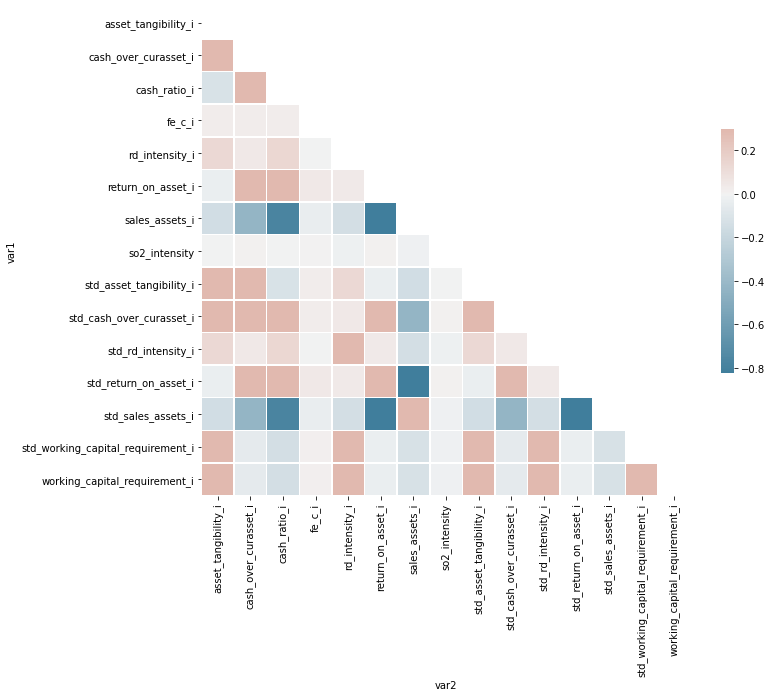

## Scatterplot

From the correlation plot above, pick up a $y$ variables.

We only plot the variables that succeed the Anova test, minus the $y$ var.

Besides, to avoid loading all the table, we have implemented the following rule:

if the size of the table is above >150K rows, then we randomly load 150K rows

First of all, you need to define the Y-axis variables

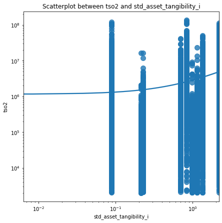

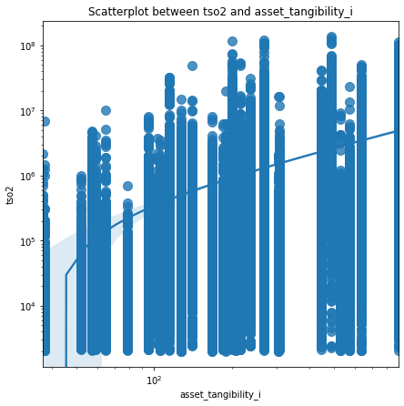

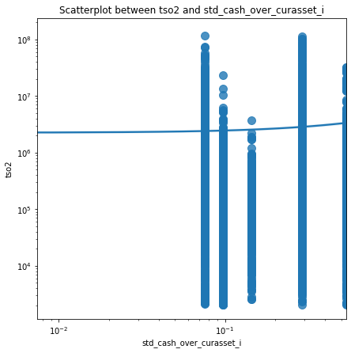

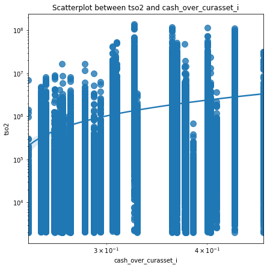

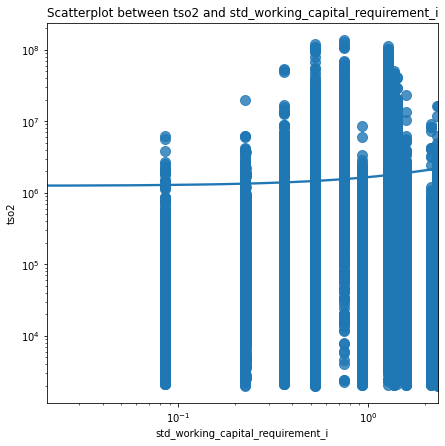

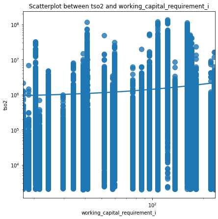

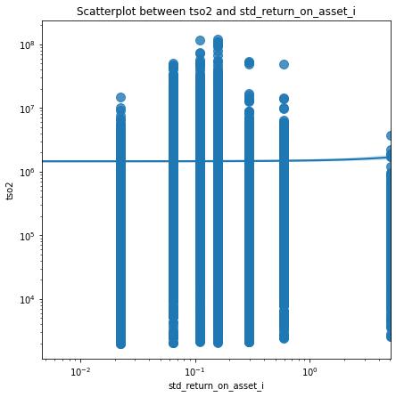

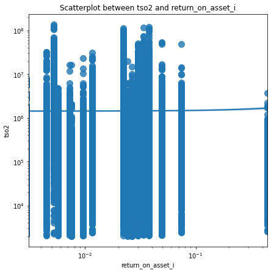

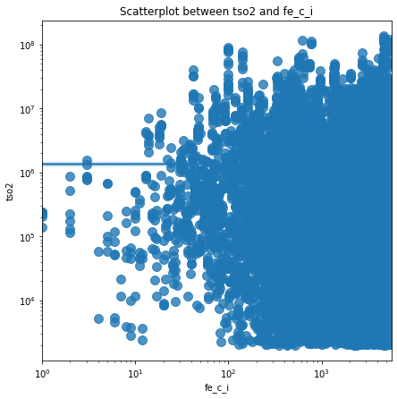

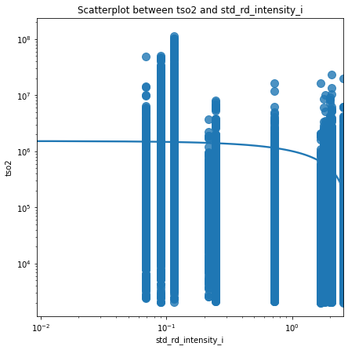

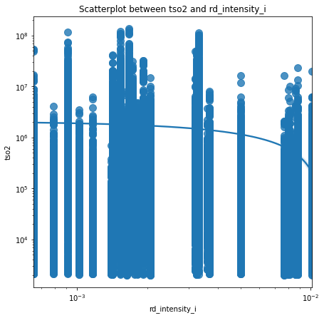

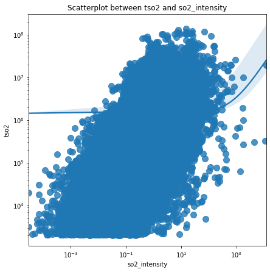

[3 more figures not shown]

### Diverging bars

The diverging bar plot is plotting for the variables to succeed the Anova test

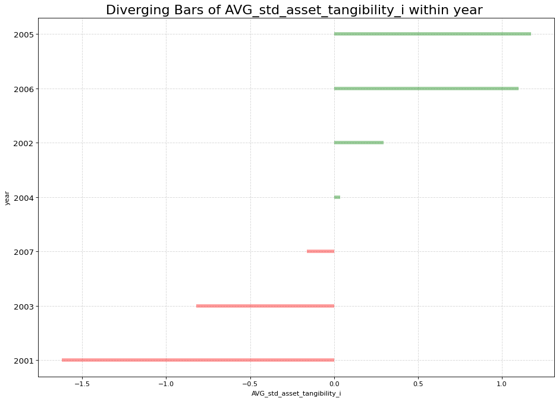

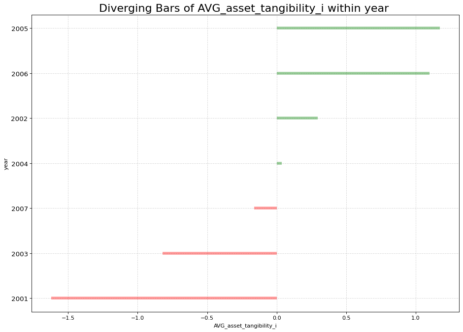

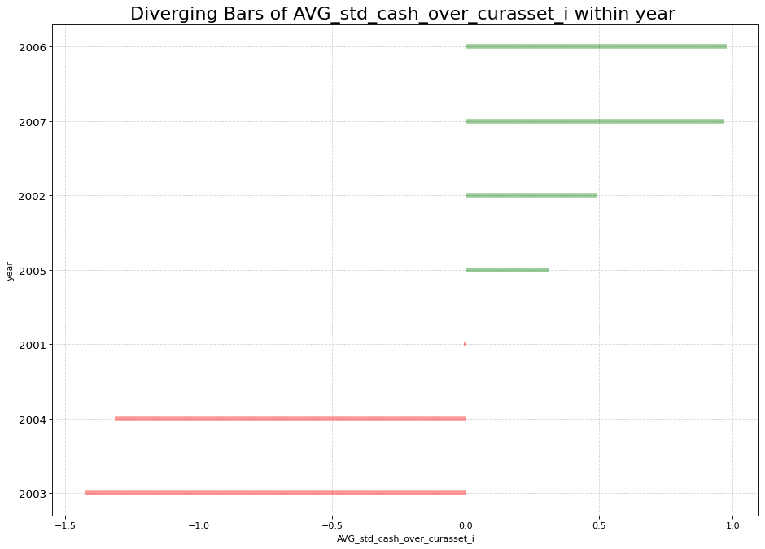

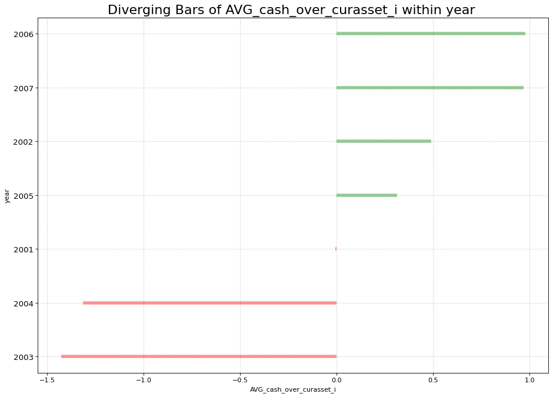

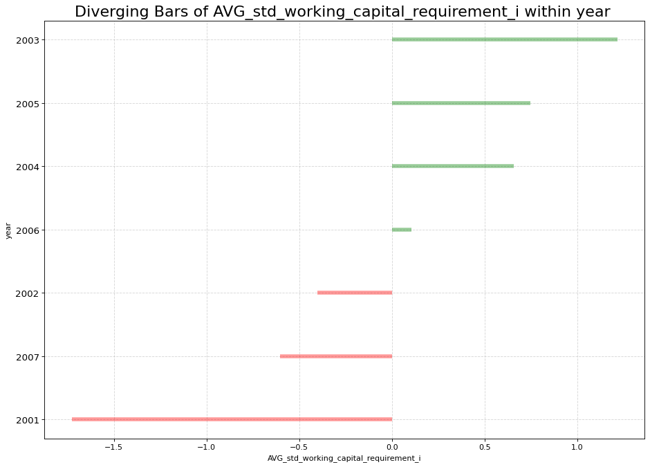

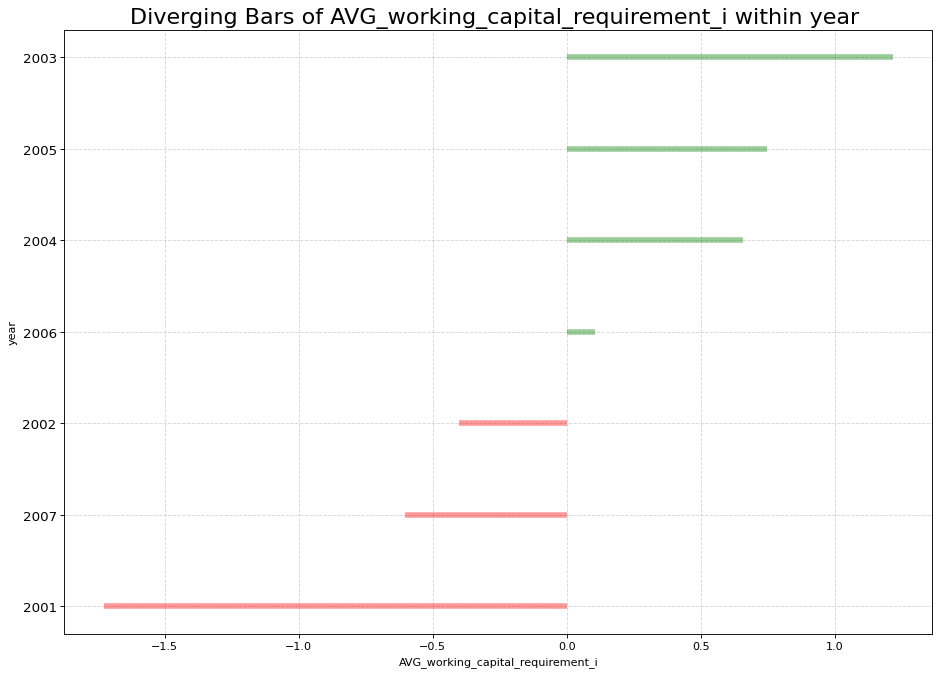

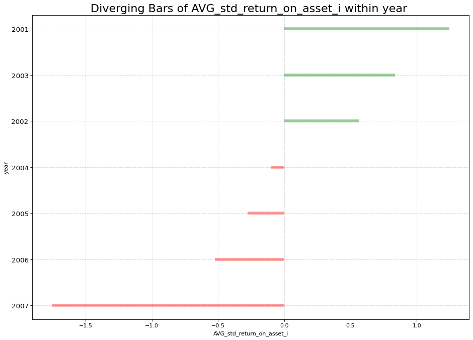

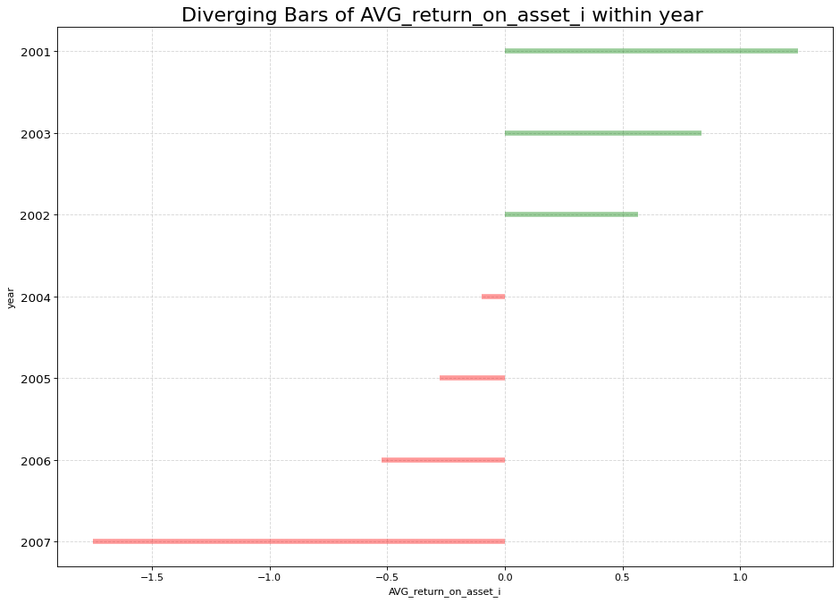

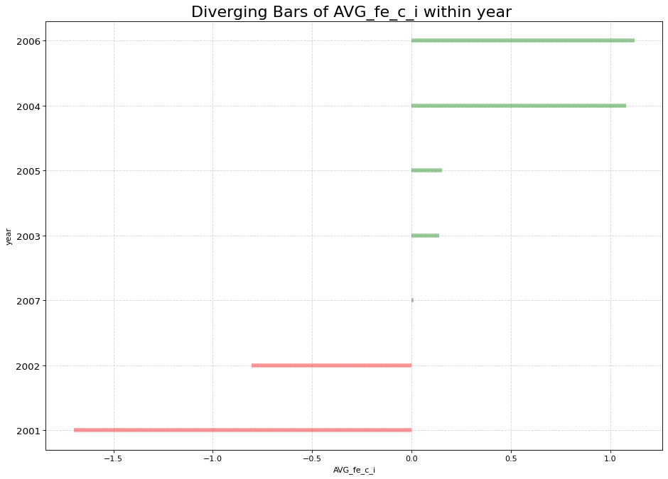

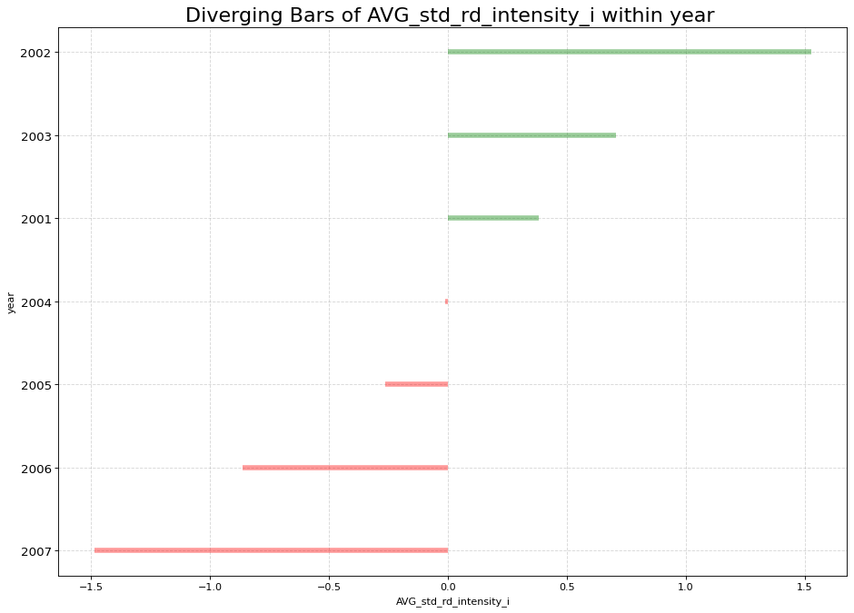

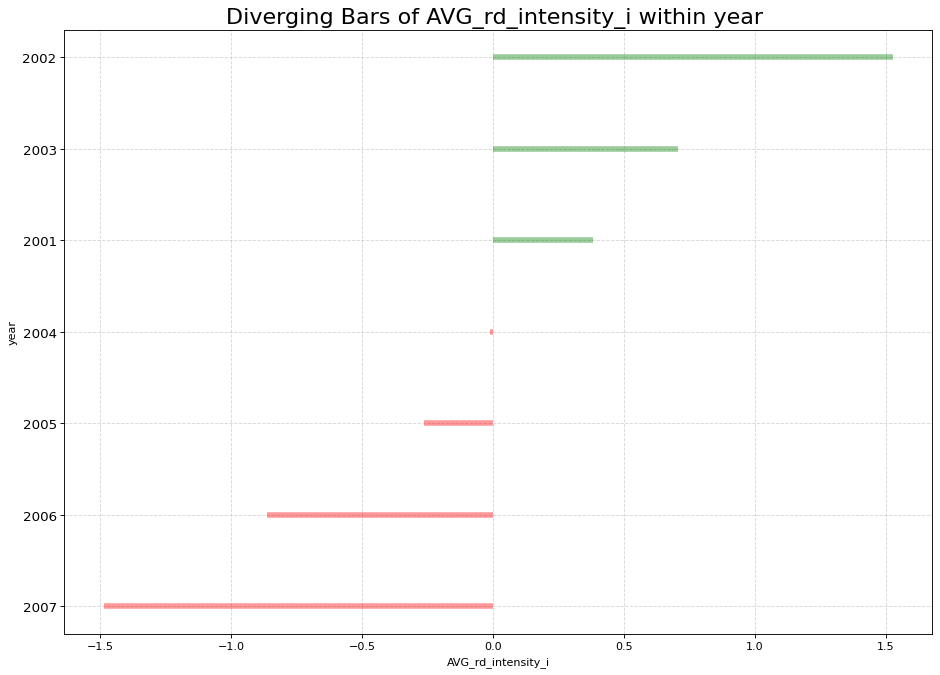

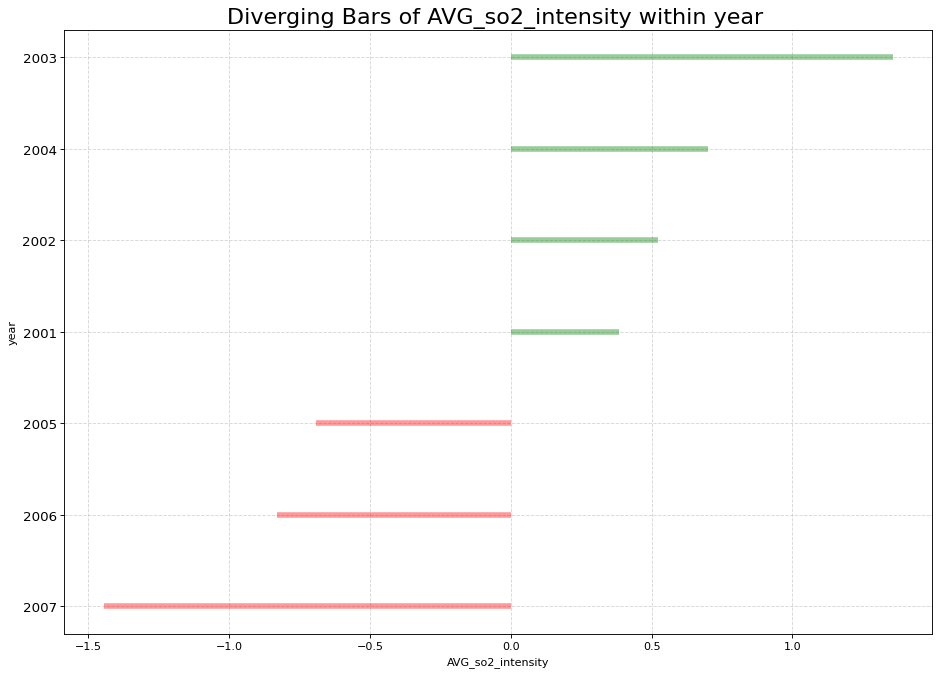

[3 more figures not shown]